# Spatial Planning and Connectivity Corpus - Technical Background Report

IPBES Spatial Planning and Connectivity Assessment

Authors

Rainer M. Krug

Gabriella Bishop

Sebastian Villasante

Doi

10.5281/zenodo.19608284

Abstract

[figure not shown]

Part of the Data Management Report

[figure not shown]

# Disclaimer

# Contributors

## Assessment Experts

- Villasante, Sebastian

## Assessment TSU

- Bishop, Gabriella

## Data and Knowledge tsu

- Niamir, Aidin
- Gudde, Renske

# LLM Usage Disclosure

Code and flowcharts in this project have been generated with the assistance of the Codex as well as Claude Code. All content and code is based on conceptuaisation by the authors and has been thoroughly reviewed and edited by humans afterwards.

# Introduction

The literature search for the Spatial Planning and Connectivity assessment corpus was conducted using search terms provided by the experts and refined in co-operation with the IPBES task force for data and knowledge management. The search was conducted using [OpenAlex](https://openalex.org), scripted from [R](https://cran.r-project.org) to use the [OpenAlex API](https://docs.openalex.org). Search terms for the following searches were defined:

- **Spatial Planning and Connectivity**,
- **Nature / Environment**
- **additional search terms** for specific corpora

To assess the quality of the corpus, sets of key papers were selected by the experts to verify if these are in the corpus.

The following searches are conducted on Title and Abstract only to account for fluctuating availability of full text searches and make the search more focussed..

## Schematic Overview

This is a schematic overview of the search strategy. It is shown again in the Results section with the numbers of resulting hits. ### Overview

```
%%{init: {'flowchart': {'htmlLabels': true}}}%%
flowchart TD
    Start([Start literature search]) --> SPC["<u><span style='color:#1a0dab;'>spc_corpus.yaml<br/>Assemble base SPC corpus</span></u>"]
    click SPC "./input/search_terms/spc_corpus.yaml" "Open spc_corpus.yaml"
    SPC --> SPC_list["spc keyword set<br/>(planning & connectivity terms)<br/>(n = <<SPC_LIST>>)"
]
    SPC --> NATURE_list["nature keyword set<br/>(environmental context terms)<br/>(n = <<NATURE_LIST>>)"
]
    SPC_list --> BaseQuery["Level 1 query<br/>spc terms AND nature dictionary<br/>(n = <<BASE_QUERY>>)"
]
    NATURE_list --> BaseQuery

    BaseQuery --> ChapterSelect{Apply chapter / theme refinements}

    ChapterSelect --> CH1["<u><span style='color:#1a0dab;'>Chapter 1<br/>chapter_1.yaml<br/>Governance & planning principles</span></u>"]
    click CH1 "./input/search_terms/chapter_1.yaml" "Open chapter_1.yaml"
    ChapterSelect --> CH2["<u><span style='color:#1a0dab;'>Chapter 2<br/>chapter_2.yaml<br/>GBF targets, nexus themes, SDGs</span></u>"]
    click CH2 "./input/search_terms/chapter_2.yaml" "Open chapter_2.yaml"
    ChapterSelect --> CH3["<u><span style='color:#1a0dab;'>Chapter 3<br/>chapter_3.yaml<br/>Restoration & conservation planning</span></u>"]
    click CH3 "./input/search_terms/chapter_3.yaml" "Open chapter_3.yaml"
    ChapterSelect --> CH4["<u><span style='color:#1a0dab;'>Chapter 4<br/>chapter_4.yaml<br/>Connectivity evidence & metrics</span></u>"]
    click CH4 "./input/search_terms/chapter_4.yaml" "Open chapter_4.yaml"
    ChapterSelect --> CH5["<u><span style='color:#1a0dab;'>Chapter 5<br/>chapter_5.yaml<br/>Foresight & futures (sections, themes, cross-cutting)</span></u>"]
    click CH5 "./input/search_terms/Chapter_5_1_2.yaml" "Open Chapter 5 search terms"
    ChapterSelect --> CH6["<u><span style='color:#1a0dab;'>Chapter 6<br/>chapter_6.yaml (+ chapter_6_r2.yaml optional)<br/>Enabling environment</span></u>"]
    click CH6 "./input/search_terms/chapter_6.yaml" "Open chapter_6.yaml"
```

### Chapter 1

```
%%{init: {'flowchart': {'htmlLabels': true}}}%%
flowchart LR
    Start([SPC Corpus]) --> Ch1["<u><span style='color:#1a0dab;'>chapter_1.yaml<br/>Level 2 refinements</span></u>"]
    click Ch1 "./input/search_terms/chapter_1.yaml" "Open chapter_1.yaml"

    subgraph Chapter1Sets["Chapter 1 thematic searches"]
        direction TB
        C1_1["Set 1:<br/>land/spatial planning<br/>+ biodiversity goals<br/>+ societal needs/values<br/>(n = <<C1_1>>)"]
        C1_2.1["Set 2.1:<br/>???<br/>(n = <<C1_2.1>>)"]
        C1_2.2["Set 2.2:<br/>???<br/>(n = <<C1_2.2>>)"]
        C1_3["Set 3:<br/>evidence & precaution<br/>+ ILK knowledge base<br/>(n = <<C1_3>>)"]
        %% C1_4["Set 4:<br/>multilevel/transparent governance<br/>+ customary coherence<br/>(n = <<C1_4>>)"]
        %% C1_5["Set 5:<br/>participatory planning<br/>+ co-design / engagement<br/>(n = <<C1_5>>)"]
        %% C1_6["Set 6:<br/>equity / rights / tenure<br/>+ justice outcomes<br/>(n = <<C1_6>>)"]
        %% C1_7["Set 7:<br/>connectivity (land-sea/cross-scale)<br/>+ nexus & climate links<br/>(n = <<C1_7>>)"]
    end

    Ch1 --> C1_1
    Ch1 --> C1_2.1
    Ch1 --> C1_2.2
    Ch1 --> C1_3
    %% Ch1 --> C1_4
    %% Ch1 --> C1_5
    %% Ch1 --> C1_6
    %% Ch1 --> C1_7
```

#### Search Terms

Click chapter_1.yaml to download

```r
params$search_terms$chapter_1 |>
  yaml::as.yaml() |>
  cat()
```

```
Set 1:
- ((indigenous AND (knowledge OR perspectives OR governance OR rights OR values OR
  practices OR land)) OR "local knowledge" OR biocultural OR customary OR (diverse
  AND ("knowledge systems" OR "world views" OR worldviews))) AND
- (planning OR governance OR policy OR tenure OR rights) AND
- (just OR inclusive OR fair OR effective OR equity OR equitable) AND
- (area OR territory OR "land use" OR "sea use" OR marine OR coastal OR "land-sea")
Set 2.1:
- ("multi-level" OR integrated OR accountable OR customary OR diverse OR "context-dependent"
  OR "cross-scale" OR polycentric OR pluralism OR adaptive) AND
- (governance OR policy OR framework) AND
- ("spatial planning" OR "marine planning" OR "land-use planning" OR "sea-use planning"
  OR "coastal planning" OR "territorial planning")
Set 2.2:
- ("legal pluralism" OR "institutional diversity" OR "polycentric governance" OR "multi-level
  governance" OR "customary governance" OR "co-management" OR "adaptive governance"
  OR "integrated governance" OR "cross-scale governance") AND
- (institution OR authority OR legitimacy) AND
- ("spatial planning" OR "marine planning" OR "land-use planning" OR "sea-use planning"
  OR "coastal planning" OR "territorial planning")
Set 3:
- (participatory OR stakeholder OR transformative OR adaptive OR integrated) AND
- (approach OR strategy OR practice OR policy OR framework) AND
- ((spatial OR marine OR "land-use" OR "sea-use" OR coastal OR territorial) AND planning)
  AND
- (landscape OR seascape OR watershed OR ecosystem OR area OR region OR "land-sea"
  OR connectivity OR marine OR ocean OR maritime)
```

### Chapter 2

```
%%{init: {'flowchart': {'htmlLabels': true}}}%%
flowchart LR
    Start([SPC Corpus]) --> Ch2L2["<u><span style='color:#1a0dab;'>chapter_2.yaml<br/>Level 2 GBF bundles</span></u>"]
    click Ch2L2 "../search_terms/chapter_2.yaml" "Open chapter_2.yaml"

    subgraph Chapter2Sets["GBF contexts & targets"]
        direction TB
        Set_11["Set 1.1<br/>(n = <<Set_11>>)"]
        Set_12["Set 1.2<br/>(n = <<Set_12>>)"]
        Set_13["Set 1.3<br/>(n = <<Set_13>>)"]
        Set_14["Set 1.3<br/>(n = <<Set_14>>)"]
        Set_21["Set 2.1<br/>(n = <<Set_21>>)"]
        Set_22["Set 2.2<br/>(n = <<Set_22>>)"]
        %% Set_3["Set 3<br/>(n = <<Set_3>>)"]
    end
    Ch2L2 --> Set_11
    Ch2L2 --> Set_12
    Ch2L2 --> Set_13
    Ch2L2 --> Set_21
    Ch2L2 --> Set_22
    %% Ch2L2 --> Set_3

    %% subgraph L1_TARGET["GBF contexts & targets"]
    %%     T3["Target 3<br/>(n = <<T3>>)"]
    %%     T4["Target 4<br/>(n = <<T4>>)"]
    %%     T5["Target 5<br/>(n = <<T5>>)"]
    %%     T6["Target 6<br/>(n = <<T6>>)"]
    %%     T7["Target 7<br/>(n = <<T7>>)"]
    %%     T8["Target 8<br/>(n = <<T8>>)"]
    %%     T9["Target 9<br/>(n = <<T9>>)"]
    %%     T10["Target 10<br/>(n = <<T10>>)"]
    %%     T11["Target 11<br/>(n = <<T11>>)"]
    %%     T12["Target 12<br/>(n = <<T12>>)"]
    %%     T13["Target 13<br/>(n = <<T13>>)"]
    %%     T14["Target 14<br/>(n = <<T14>>)"]
    %%     T15["Target 15<br/>(n = <<T15>>)"]
    %%     T16["Target 16<br/>(n = <<T16>>)"]
    %%     T17["Target 17<br/>(n = <<T17>>)"]
    %%     T18["Target 18<br/>(n = <<T18>>)"]
    %%     T19["Target 19<br/>(n = <<T19>>)"]
```

[output cut: 70 more lines]

```
    %% Ch2L4 --> SDG3
    %% Ch2L4 --> SDG4
    %% Ch2L4 --> SDG5
    %% Ch2L4 --> SDG6
    %% Ch2L4 --> SDG7
    %% Ch2L4 --> SDG8
    %% Ch2L4 --> SDG9
    %% Ch2L4 --> SDG10
    %% Ch2L4 --> SDG11
    %% Ch2L4 --> SDG12
    %% Ch2L4 --> SDG13
    %% Ch2L4 --> SDG14
    %% Ch2L4 --> SDG15
    %% Ch2L4 --> SDG16
    %% Ch2L4 --> SDG17
```

#### Search Terms

Click chapter_2.yaml to download

```r
params$search_terms$chapter_2 |>
  yaml::as.yaml() |>
  cat()
```

```
Set 1.1:
- (((spatial OR "land use" OR regional OR municipal OR landscape OR design OR territorial
  OR development OR marine OR urban OR conservation) AND (plan)) OR zoning) AND
- (GIS OR scenario OR modelling OR participatory OR synergies OR "trade-offs" OR "remote
  sensing" OR "spatial prioritization")
Set 1.2:
- (((spatial OR "land use" OR regional OR municipal OR landscape OR design OR territorial
  OR development OR marine OR urban OR conservation) AND (plan)) OR zoning) AND
- ("multi-criteria")
Set 1.3:
- (((spatial OR "land use" OR regional OR municipal OR landscape OR design OR territorial
  OR development OR marine OR urban OR conservation) AND (plan)) OR zoning) AND
- (optimization OR monitoring OR indicators OR "community-based")
Set 1.4:
- (((spatial OR "land use" OR regional OR municipal OR landscape OR design OR territorial
  OR development OR marine OR urban OR conservation) AND (plan)) OR zoning) AND
- (((impact OR environmental OR risk) AND assessment) OR ((spatial OR "cost-benefit")
  AND analysis))
Set 2.1: (biodiversity OR ecosystem OR nature OR seascape OR agriculture OR forest
  OR coastal OR marine OR "green infrastructure" OR "blue infrastructure" OR "protected
  area" OR fragmentation OR connectivity OR biocultural)
Set 2.2: (urban OR culture OR stewardship OR "traditional ecological knowledge" OR
  "indigenous knowledge" OR kinship OR reciprocity OR "socio-ecological systems")
```

Non implemented additional searches are:

- Click chapter_2_add.yaml to download
- Click chapter_2_sdg.yaml to download

### Chapter 3

```
%%{init: {'flowchart': {'htmlLabels': true}}}%%
flowchart LR
    Start([SPC Corpus]) --> Ch3["<u><span style='color:#1a0dab;'>chapter_3.yaml<br/>Level 2 refinements</span></u>"]
    click Ch3 "./input/search_terms/chapter_3.yaml" "Open chapter_3.yaml"

    subgraph Chapter3Sets["Chapter 3 searches"]
        direction TB
        C3_1["Set 1:<br/>Protected/OECM + NBSAP + cases<br/>+ spatial prioritization + regional scales<br/>(n = <<C3_1>>)"]
        C3_3["Set 3:<br/>Restoration planning + connectivity + resilience<br/>(n = <<C3_3>>)"]
        C3_3.1A["Set 3.1 A:<br/>Objective<br/>(n = <<C3_3.1A>>)"]
        C3_3.1BCD["Set 3.1 BCD:<br/>Concept<br/>(n = <<C3_3.1BCD>>)"]
        C3_3.2D["Set 3.2 D:<br/>???<br/>(n = <<C3_3.2D>>)"]
        C3_3.2F["Set 3.2 F:<br/>???<br/>(n = <<C3_3.2F>>)"]
        C3_3.3["Set 3.3:<br/>???<br/>(n = <<C3_3.3>>)"]
        C3_4["Set 4:<br/>Systematic conservation planning / gap analysis<br/>(n = <<C3_4>>)"]
        C3_4.1AB["Set 4.1 AB:<br/>???<br/>(n = <<C3_4.1AB>>)"]
        C3_4.1CD["Set 4.1 CD:<br/>???<br/>(n = <<C3_4.1CD>>)"]
        C3_4.2["Set 4.2:<br/>???<br/>(n = <<C3_4.2>>)"]

        C3_5.1["Set 5.1:<br/>???<br/>(n = <<C3_5.1>>)"]
        C3_5.2["Set 5.1:<br/>???<br/>(n = <<C3_5.2>>)"]
    end
    Ch3 --> C3_1
    Ch3 --> C3_3
    Ch3 --> C3_3.1A
    Ch3 --> C3_3.1BCD
    Ch3 --> C3_3.2D
    Ch3 --> C3_3.2F
    Ch3 --> C3_3.3
    Ch3 --> C3_4
    Ch3 --> C3_4.1AB
    Ch3 --> C3_4.1CD
    Ch3 --> C3_4.2
    Ch3 --> C3_5.1
    Ch3 --> C3_5.2
```

#### Search Terms

Click chapter_3.yaml to download

```r
params$search_terms$chapter_3 |>
  yaml::as.yaml() |>
  cat()
```

```
Set 1:
- (((protected OR conserved OR Indigenous) AND areas) OR OECM OR "other effective
  area-based conservation measures" OR ITT OR "indigenous and traditional territories")
  AND
- (NBSAP OR target OR (National AND ("Biodiversity Strategy")))  AND
- (regional OR national OR subnational OR marine OR interpretation OR interpret OR
  implement OR implementation OR adapt OR adaptation OR translate OR translation governance
  OR "decision-making" OR transboundary)
Set 3:
- (ecology OR ecological OR biodiversity OR habitat OR ecosystem) AND
- (restoration OR rewilding) AND
- (spatial AND (planning OR prioritization OR prioritisation))
Set 3.1A:
- (ecology OR ecological OR biodiversity OR habitat OR ecosystem) AND
- (restoration OR rewilding) AND
- (spatial AND (planning OR prioritization OR prioritisation)) AND
- (goal OR objective)
Set 3.1BCD:
- (ecology OR ecological OR biodiversity OR habitat OR ecosystem) AND
- (restoration OR rewilding) AND
- (spatial AND (planning OR prioritization OR prioritisation)) AND
- (concept OR principle)
Set 3.2CE:
- (ecology OR ecological OR biodiversity OR habitat OR ecosystem) AND
- (restoration OR rewilding) AND
- (spatial AND (planning OR prioritization OR prioritisation)) AND
- ("multi-criteria" OR "multi-objective" OR multicriteria OR (multiple AND (criteria
  OR objective OR goal)))
Set 3.2D:
- (ecology OR ecological OR biodiversity OR habitat OR ecosystem) AND
- (restoration OR rewilding) AND
- (spatial AND (planning OR prioritization OR prioritisation)) AND
- (method OR tool OR approach OR software)
Set 3.2F:
- (ecology OR ecological OR biodiversity OR habitat OR ecosystem) AND
- (restoration OR rewilding) AND
- (spatial AND (planning OR prioritization OR prioritisation)) AND
- (inclusivity OR participation OR "co-management" OR "Indigenous knowledge" OR "traditional
  ecological knowledge" OR ILK OR "local knowledge" OR "community-based restoration"
  OR "stakeholder engagement" OR "social equity" OR justice)
```

[output cut: 19 more lines]

```
Set 4.2:
- (conservation OR biodiversity OR "protected area" OR OECM or reserve) AND
- (indicator OR index OR metric OR objective)
Set 5.1:
- (conservation OR biodiversity OR "protected area" OR OECM OR reserve) AND
- restoration AND
- spatial AND
- (planning OR prioritization OR prioritisation)
Set 5.2:
- ("adaptive management" OR "adaptive co-management" OR "adaptive comanagement" OR
  "learning-based management" OR "iterative management") AND
- ("protected area" OR park OR reserve OR "conservation area" OR "biodiversity conservation"
  OR "ecological restoration" OR "habitat restoration" OR "ecosystem restoration")
  AND
- (planning OR implementation)
```

### Chapter 4

```
%%{init: {'flowchart': {'htmlLabels': true}}}%%
flowchart LR
    Start([SPC Corpus]) --> Ch4["<u><span style='color:#1a0dab;'>chapter_4.yaml<br/>Level 2 refinements</span></u>"]
    click Ch4 "./input/search_terms/chapter_4.yaml" "Open chapter_4.yaml"

    subgraph Chapter4Sets["Chapter 4 searches"]
        direction TB
        C4_1["Set 1:<br/>Connectivity review articles<br/>(n = <<C4_1>>)"]
        C4_2["Set 2:<br/>Connectivity benefits vs risks<br/>+ ecosystem services<br/>(n = <<C4_2>>)"]
        C4_3["Set 3:<br/>Structural vs functional connectivity<br/>(n = <<C4_3>>)"]
        C4_4["Set 4:<br/>Connectivity modelling toolkits<br/>(n = <<C4_4>>)"]
        C4_5["Set 5:<br/>Connectivity indicators & metrics<br/>(n = <<C4_5>>)"]
        C4_6["Set 6:<br/>Policy & governance integration<br/>(n = <<C4_6>>)"]
        C4_7["Set 7:<br/>Multilevel / transboundary governance<br/>+ IPLC inclusion + land tenure<br/>(n = <<C4_7>>)"]
        C4_8["Set 8:<br/>Movement ecology<br/>(dispersal / migration / permeability)<br/>(n = <<C4_8>>)"]
    end
    Ch4 --> C4_1
    Ch4 --> C4_2
    Ch4 --> C4_3
    Ch4 --> C4_4
    Ch4 --> C4_5
    Ch4 --> C4_6
    Ch4 --> C4_7
    Ch4 --> C4_8
```

#### Search Terms

Click chapter_4.yaml to download

```r
params$search_terms$chapter_4 |>
  yaml::as.yaml() |>
  cat()
```

```
Set 1: '"ecological connectivity"'
Set 2: ("ecological connectivity" OR "habitat connectivity" OR "landscape connectivity"
  OR "wildlife corridor" OR "biological corridor") AND (benefits OR advantages OR
  positive OR impacts OR opportunities) AND (risks OR drawbacks OR negative OR impacts
  OR challenges) AND ("ecosystem services" OR "ecosystem management")
Set 3:
- '"structural connectivity" OR'
- '"functional connectivity"'
Set 4:
- '"connectivity analysis" OR'
- '"network analysis" OR'
- '"circuit theory" OR'
- '"least-cost path" OR'
- '"graph theory" OR'
- '"resistant kernels" OR'
- '"agent-based models" OR'
- Conefor OR
- '"pattern-oriented model" OR'
- '"state-space model" OR'
- '"corridor model" OR'
- '"simulated individual" OR'
- '"movement paths" OR'
- '"hidden Markov models" OR'
- '"effective connectivity" OR'
- '"gene flow"'
Set 5: '"ecological connectivity" AND (indicator OR index OR "metric*" OR objective)'
Set 6:
- ("ecological connectivity" OR "landscape connectivity" OR "functional connectivity"
  OR "connectivity conservation") AND
- (policy OR framework OR governance OR "planning instrument" OR initiative OR agreement
  OR global OR international OR "regional strategy" OR "transboundary cooperation"
  OR "joint management" OR "cross-border conservation" OR "bioregional planning")
Set 7:
- ("ecological connectivity" OR "spatial governance") AND
- ("multi-level governance" OR "cross-scale governance" OR "transboundary governance")
  AND
- ("inclusive governance" OR "community-based management" OR "co-management") AND
- ("Indigenous Peoples" OR "Local Communities" OR IPLCs) AND
- ("policy coherence" OR "cross-sectoral integration") AND
- ("land tenure" OR "property rights" OR "private land conservation")
Set 8:
- dispersal OR
- migration OR
- nomadism OR
- '"landscape permeability"'
```

### Chapter 5

```
%%{init: {'flowchart': {'htmlLabels': true}}}%%
flowchart LR
    Start([SPC Corpus]) --> Ch5L2["<u><span style='color:#1a0dab;'>chapter_5.yaml<br/>Level 2 foresight framing</span></u>"]
    click Ch5L2 "./input/search_terms/chapter_5.yaml" "Open chapter_5.yaml"

    subgraph L2Sets["Section 5.1–5.2 searches"]
        direction TB
        C5_1["Set 1:<br/>Future + project*/predict*/scenario<br/>(n = <<C5_1>>)"]
        C5_2["Set 2:<br/>Future + pathway*/narrative*/vision*<br/>(n = <<C5_2>>)"]
        C5_3["Set 3:<br/>Future-proof*/anticipat*/scenario planning<br/>(n = <<C5_3>>)"]
        C5_4["Set 4:<br/>Foresight*/backcasting/simulat*/trend*<br/>(n = <<C5_4>>)"]
        C5_5["Set 5:<br/>Model* AND scenario<br/>(n = <<C5_5>>)"]
    end
    Ch5L2 --> C5_1
    Ch5L2 --> C5_2
    Ch5L2 --> C5_3
    Ch5L2 --> C5_4
    Ch5L2 --> C5_5

    subgraph L3Sets["Section 5.3 searches"]
        direction TB
        C5_3a["Set 1:<br/>Drivers of change<br/>(n = <<C5_3a>>)"]
        C5_3b["Set 2:<br/>Driver modelling approaches<br/>(n = <<C5_3b>>)"]
        C5_3c["Set 3:<br/>Driver gaps<br/>(n = <<C5_3c>>)"]
    end
    Ch5L2 --> C5_3a
    Ch5L2 --> C5_3b
    Ch5L2 --> C5_3c

    subgraph L4Sets["Section 5.4 searches"]
        direction TB
        C5_4a["Set 1:<br/>Interactions (synergy/trade-off/nexus)<br/>(n = <<C5_4a>>)"]
        C5_4b["Set 2:<br/>Response options (integrated planning / NbS)<br/>(n = <<C5_4b>>)"]
        C5_4c["Set 3:<br/>Cross-scale synergy & trade-off terms<br/>(n = <<C5_4c>>)"]
    end
    Ch5L2 --> C5_4a
    Ch5L2 --> C5_4b
    Ch5L2 --> C5_4c

    subgraph L5Sets["Section 5.5 searches"]
```

[output cut: 15 more lines]

```
        C5_6c["Set 3:<br/>Enabling factors & coordination<br/>(n = <<C5_6c>>)"]
        C5_6d["Set 4:<br/>Shocks, surprises, uncertainties<br/>(n = <<C5_6d>>)"]
    end
    Ch5L2 --> C5_6a
    Ch5L2 --> C5_6b
    Ch5L2 --> C5_6c
    Ch5L2 --> C5_6d

    subgraph CCSets["Cross-cutting searches"]
        direction TB
        CC1["Set 1:<br/>Scales & telecoupling<br/>(n = <<CC1>>)"]
        CC2["Set 2:<br/>Co-production & inclusion<br/>(n = <<CC2>>)"]
    end
    Ch5L2 --> CC1
    Ch5L2 --> CC2
```

#### Search Terms

Click chapter_5.yaml to download

```r
params$search_terms$chapter_5 |>
  yaml::as.yaml() |>
  cat()
```

```
Sections 1 and 2:
  Set 1: Future AND (projection OR projected OR predicted OR prediction OR forecast
    OR scenario)
  Set 2: Future AND (pathway OR narrative OR storyline OR foresight OR vision OR horizon
    scan OR trajectory OR imagination)
  Set 3:
  - '"future-proof" OR'
  - anticipate OR
  - '"forward-looking" OR'
  - '"futures thinking" OR'
  - '"future-oriented" OR'
  - prospective OR
  - '"plausible future" OR'
  - '"scenario planning"'
  Set 4:
  - Foresight OR
  - backcasting OR
  - simulate OR
  - simulation OR
  - '"delphi method" OR'
  - storytelling OR
  - '"environmental scan" OR'
  - trend OR
  - megatrend
  Set 5: (model AND scenario)
Section 3:
  Set 1:
  - '"drivers of change" OR'
  - '"biodiversity driver" OR'
  - '"social-ecological driver" OR'
  - '"technological driver" OR'
  - '"perennial driver" OR'
  - '"emerging driver" OR'
  - '"cascading driver"'
  Set 2:
  - '"Integrated assessment" OR'
  - '"land-use change model" OR'
  - '"Scenario model" OR'
  - '"Social-ecological model" OR'
  - '"agent-based model" OR'
```

[output cut: 80 more lines]

```
  - Customary OR
  - tenure OR
  - Participatory OR
  - '"Cross-cultural" OR'
  - '"knowledge integration" OR'
  - ((Gender OR Social) AND Inclusion) OR
  - '"Gender-responsive" OR'
  - Intersectionality OR
  - equity OR
  - '"Women’s roles" OR'
  - '"Women''s roles" OR'
  - '"Women`s roles" OR'
  - Gendered OR
  - Empowerment OR
  - '"capacity-building"'
```

### Chapter 6

```
%%{init: {'flowchart': {'htmlLabels': true}}}%%
flowchart LR
    Start([SPC Corpus]) --> Ch6["<u><span style='color:#1a0dab;'>chapter_6.yaml<br/>Level 2 refinements</span></u>"]
    click Ch6 "./input/search_terms/chapter_6.yaml" "Open chapter_6.yaml"

    subgraph Chapter6Sets["Chapter 6 searches"]
        direction TB
        C6_1["Set 1:<br/>Institutional & governance structures<br/>(n = <<C6_1>>)"]
        C6_2["Set 2:<br/>Political & strategic leadership<br/>(n = <<C6_2>>)"]
        C6_3["Set 3:<br/>Socio-cultural & stakeholder engagement<br/>(n = <<C6_3>>)"]
        C6_4["Set 4:<br/>Collaboration, trust & networks<br/>(n = <<C6_4>>)"]
        C6_5["Set 5:<br/>Financial & economic mechanisms<br/>(n = <<C6_5>>)"]
        C6_6["Set 6:<br/>Legal & policy frameworks<br/>(n = <<C6_6>>)"]
        C6_7["Set 7:<br/>Human & institutional capacity<br/>(n = <<C6_7>>)"]
        C6_8["Set 8:<br/>Data, knowledge & decision support (8.1 + 8.2)<br/>(n = <<C6_8>>)"]
        C6_9["Set 9:<br/>Ecological & spatial planning tools<br/>(n = <<C6_9>>)"]
        C6_10["Set 10:<br/>Cross-cutting process enablers<br/>(n = <<C6_10>>)"]
    end
    Ch6 --> C6_1
    Ch6 --> C6_2
    Ch6 --> C6_3
    Ch6 --> C6_4
    Ch6 --> C6_5
    Ch6 --> C6_6
    Ch6 --> C6_7
    Ch6 --> C6_8
    Ch6 --> C6_9
    Ch6 --> C6_10

Ch6R2["<u><span style='color:#1a0dab;'>chapter_6_r2.yaml<br/>Optional Level 3 filter</span></u>"]
Chapter6Sets --> Ch6R2
click Ch6R2 "./input/search_terms/chapter_6_r2.yaml" "Open chapter_6_r2.yaml"
subgraph Chapter6Case["Chapter 6 searches"]
    R2["Case-study keywords<br/>(case stud*, example*, initiative*, etc.)"]
end
Ch6R2 --> R2
```

#### Search Terms

Click chapter_6.yaml to download

```r
params$search_terms$chapter_6 |>
  yaml::as.yaml() |>
  cat()
```

```
Set 1:
- '"institutional arrangements" OR'
- '"governance structures" OR'
- '"cross-sector coordination" OR'
- '"multi-level governance" OR'
- '"inter-agency collaboration" OR'
- '"policy coherence" OR'
- '"environmental governance" OR'
- '"landscape governance" OR'
- '"seascape governance" OR'
- '"integrated landscape management"'
Set 2:
- '"political support" OR'
- '"environmental leadership" OR'
- '"ministerial alignment" OR'
- '"strategic prioritization" OR'
- '"national biodiversity strategy"'
Set 3:
- '"stakeholder engagement" OR'
- participation OR
- '"co-design" OR'
- '"co-production" OR'
- '"community-based management" OR'
- '"indigenous governance" OR'
- '"traditional knowledge" OR'
- '"Free Prior and Informed Consent" OR'
- FPIC OR
- '"stakeholder workshops" OR'
- '"stakeholder dialogues" OR'
- '"public consultation"'
Set 4:
- collaboration OR
- trust OR
- partnership OR
- '"multi-stakeholder platform" OR'
- coalition OR
- '"inter-organizational network" OR'
- cooperation
Set 5:
- '"biodiversity finance" OR'
```

[output cut: 66 more lines]

```
- '"ecological networks" OR'
- '"ecological corridors" OR'
- '"green infrastructure" OR'
- '"nature-based Strategic spatial planning solutions" OR'
- '"restoration planning" OR'
- '"blue infrastructure" OR'
- '"blue-green infrastructure" OR'
- '"spatial decision-making" OR'
- '"strategic spatial planning"'
Set 10:
- '"adaptive management" OR'
- '"feedback mechanisms" OR'
- '"monitoring and learning" OR'
- '"institutional innovation" OR'
- '"continuous improvement"'
```

Non implemented additional searches are:

- Click chapter_6_r2.yaml to download

## Type Selsection

OpenAlex contains more then 270 million works of different types. The following table shows and explains the available types and highlights which are selected to be included in the SPC Corpus.

```r
params$types |>
  knitr::kable(
    caption = "OpenAlex Work Types and Inclusion in the SPC Corpus",
    booktabs = TRUE,
    align = c("l", "l", "l", "c")
  ) # |>
```

OpenAlex Work Types and Inclusion in the SPC Corpus

| Type | Description | Included |
| --- | --- | --- |
| article | Scholarly journal articles and related periodical works | TRUE |
| book | Monographs and other long-form published books | TRUE |
| book-chapter | Chapters published within edited books or proceedings | TRUE |
| dissertation | Doctoral or master level theses and dissertations | TRUE |
| editorial | Editorials and editor introductions | TRUE |
| preprint | Pre-publication manuscripts shared prior to peer review | TRUE |
| report | Technical, institutional, or policy reports | TRUE |
| review | Narrative or systematic review articles | TRUE |
| dataset | Published datasets and structured data releases | FALSE |
| erratum | Published corrections to previously released works | FALSE |
| grant | Summaries or descriptions of grant-funded projects | FALSE |
| letter | Correspondence, commentaries, and short letters | FALSE |
| libguides | Library research guides and curated bibliographies | FALSE |
| other | Works that do not align with a more specific OpenAlex type | FALSE |
| paratext | Prefaces, introductions, indexes, and other paratextual items | FALSE |
| peer-review | Formal peer review reports and evaluations | FALSE |
| reference-entry | Encyclopaedia or dictionary reference entries | FALSE |
| retraction | Notices retracting previously published works | FALSE |
| standard | Standards, protocols, and technical specifications | FALSE |
| supplementary-materials | Supplementary files accompanying primary publications | FALSE |

```r
# kableExtra::kable_styling(
#     full_width = FALSE,
#     position = "left"
# )
```

# Methods

## SPC Corpus

### Assess of Individual Terms in spc and nature search terms

This assessment is done on the whole of the OpenAlex corpus and only filtered for types and *not* for the date range.

```r
fn <- file.path(params$output_dir, "searchterm_assessment_spcc.rds")

if (!file.exists(fn)) {
  result <- list(
    spc = assess_search_term_both(
      st = params$search_terms$spc_corpus$spc,
      and_term = st_compact(params$search_terms$spc_corpus$spc_corpus$nature),
      types = params$types_filter,
      verbose = TRUE
    ),
    nature = assess_search_term_both(
      st = params$search_terms$spc_corpus$nature,
      and_term = st_compact(params$search_terms$spc_corpus$spc_corpus$spc),
      types = params$types_filter,
      verbose = TRUE
    )
  ) |>
    saveRDS(fn)
}
```

### Get Key Paper

Here we get key papers in a parquet database which is partitioned by:

- `found_in`: the search term or openalex which is used as the filter, i.e. the key paper occurs in corpus which would result from the search term
- `id_used`: the id used to testing,m either the OpenAlex id (id) or the doi (doi)
- `page`: only for processing reasons

No filtering, neither by type nor by publication year is done.

The other columns are as returned by the OpenAlex API.

```r
#|
dois <- params$key_papers$goldstandard$DOI[
  params$key_papers$goldstandard$DOI != ""
]
ids <- params$key_papers$goldstandard$openalex_id[
  params$key_papers$goldstandard$openalex_id != ""
]
```

```r
#|
fn <- file.path(params$keyworks, "parquet", "found_in=openalex")
if (!dir.exists(fn)) {
  ### KP in OpenAlex
  openalexPro::pro_query(
    doi = dois,
    chunk_limit = 50
  ) |>
    openalexPro::pro_request(
      output = file.path(fn, "..", "json_doi")
    ) |>
    openalexPro::pro_request_jsonl(
      output = file.path(fn, "..", "jsonl_doi"),
      delete_input = TRUE
    ) |>
    openalexPro::pro_request_jsonl_parquet(
      output = file.path(fn, "id_used=doi"),
      delete_input = TRUE
    )

  openalexPro::pro_query(
    id = ids,
    multiple_id = TRUE,
    chunk_limit = 50
  ) |>
    openalexPro::pro_request(
      output = file.path(fn, "..", "json_oa_id")
    ) |>
    openalexPro::pro_request_jsonl(
      output = file.path(fn, "..", "jsonl_oa_id"),
      delete_input = TRUE
    ) |>
    openalexPro::pro_request_jsonl_parquet(
      output = file.path(fn, "id_used=oa_id"),
      delete_input = TRUE
    )
}
```

```r
#|
fn <- file.path(params$keyworks, "parquet", "found_in=spc")
if (!dir.exists(fn)) {
  openalexPro::pro_query(
    title_and_abstract.search = st$spc,
    doi = dois,
    chunk_limit = 25
  ) |>
    openalexPro::pro_request(
      output = file.path(fn, "..", "json_doi")
    ) |>
    openalexPro::pro_request_jsonl(
      output = file.path(fn, "..", "jsonl_doi"),
      delete_input = TRUE
    ) |>
    openalexPro::pro_request_jsonl_parquet(
      output = file.path(fn, "id_used=doi"),
      delete_input = TRUE
    )

  openalexPro::pro_query(
    title_and_abstract.search = st$spc,
    id = ids,
    multiple_id = TRUE,
    chunk_limit = 25
  ) |>
    openalexPro::pro_request(output = file.path(fn, "json_oa_id")) |>
    openalexPro::pro_request_jsonl(
      output = file.path(fn, "jsonl_oa_id"),
      delete_input = TRUE
    ) |>
    openalexPro::pro_request_jsonl_parquet(
      output = file.path(fn, "id_used=oa_id"),
      delete_input = TRUE
    )
}
```

```r
#|
fn <- file.path(params$keyworks, "parquet", "found_in=nature")
if (!dir.exists(fn)) {
  ### KP in nature
  openalexPro::pro_query(
    title_and_abstract.search = st$nature,
    doi = dois,
    chunk_limit = 25
  ) |>
    openalexPro::pro_request(output = file.path(fn, "json_doi")) |>
    openalexPro::pro_request_jsonl(
      output = file.path(fn, "jsonl_doi"),
      delete_input = TRUE
    ) |>
    openalexPro::pro_request_jsonl_parquet(
      output = file.path(fn, "id_used=doi"),
      delete_input = TRUE
    )

  openalexPro::pro_query(
    title_and_abstract.search = st$nature,
    id = ids,
    multiple_id = TRUE,
    chunk_limit = 25
  ) |>
    openalexPro::pro_request(output = file.path(fn, "json_oa_id")) |>
    openalexPro::pro_request_jsonl(
      output = file.path(fn, "jsonl_oa_id"),
      delete_input = TRUE
    ) |>
    openalexPro::pro_request_jsonl_parquet(
      output = file.path(fn, "id_used=oa_id"),
      delete_input = TRUE
    )
}
```

```r
#|
fn <- file.path(params$keyworks, "parquet", "found_in=spcc")
if (!dir.exists(fn)) {
  ### KP in spcc
  openalexPro::pro_query(
    title_and_abstract.search = st$spcc,
    doi = params$key_papers$goldstandard$DOI[
      params$key_papers$goldstandard$DOI != ""
    ],
    chunk_limit = 15
  ) |>
    openalexPro::pro_request(output = file.path(fn, "json_doi")) |>
    openalexPro::pro_request_jsonl(
      output = file.path(fn, "jsonl_doi"),
      delete_input = TRUE
    ) |>
    openalexPro::pro_request_jsonl_parquet(
      output = file.path(fn, "id_used=doi"),
      delete_input = TRUE
    )

  openalexPro::pro_query(
    title_and_abstract.search = st$spcc,
    id = params$key_papers$goldstandard$openalex_id[
      params$key_papers$goldstandard$openalex_id != ""
    ],
    multiple_id = TRUE,
    chunk_limit = 25
  ) |>
    openalexPro::pro_request(output = file.path(fn, "json_oa_id")) |>
    openalexPro::pro_request_jsonl(
      output = file.path(fn, "jsonl_oa_id"),
      delete_input = TRUE
    ) |>
    openalexPro::pro_request_jsonl_parquet(
      output = file.path(fn, "id_used=oa_id"),
      delete_input = TRUE
    )
}
```

### Keypaper in Search Terms

The in the previous step retrieved works are analysed here to get a table which shows where the key paper occur.

```r
fn <- file.path(params$keyworks, "kp_found_in.rds")
if (!file.exists(fn)) {
  arrow::open_dataset(file.path(params$keyworks, "parquet")) |>
    dplyr::select(
      id,
      doi,
      type,
      found_in,
      title,
      citation
    ) |>
    dplyr::group_by(id, doi, title, citation, type) |>
    dplyr::summarise(
      in_openalex = base::max(found_in == "openalex", na.rm = TRUE),
      in_spc = base::max(found_in == "spc", na.rm = TRUE),
      in_nature = base::max(found_in == "nature", na.rm = TRUE),
      in_spcc = base::max(found_in == "spcc", na.rm = TRUE),
      .groups = "drop"
    ) |>
    dplyr::collect() |>
    saveRDS(fn)
}
```

### Get Numbers from OpenAlex of the Search Terms

These data is gathered from OpenAlex directly, not downloaded any works. The data is used to assess the quality of the TCA Corpus.

The query contains: - the search term (nature, spc, spcc) - the types selected (article, book, book-chapter, dissertation, editorial, preprint, report, review) - the date range (from 1992-01-01 to 2025-12-31)

The following counts are retrieved:

#### Overall hits

```r
#|
fn <- file.path(params$corpus, "st_hits.rds")
if (!file.exists(fn)) {
  queries <- lapply(
    st,
    function(s) {
      openalexPro::pro_query(
        title_and_abstract.search = s,
        type = params$types_filter,
        from_publication_date = params$publication_date$from,
        to_publication_date = params$publication_date$to
      )
    }
  )
  queries$openalex <- openalexPro::pro_query(
    type = params$types_filter,
    from_publication_date = params$publication_date$from,
    to_publication_date = params$publication_date$to,
  )

  results <- pbapply::pblapply(
    queries,
    function(query) {
      query |>
        openalexPro::pro_request(
          count_only = TRUE,
          verbose = TRUE
        )
    }
  ) |>
    dplyr::bind_rows() |>
    dplyr::select(count)
  rownames(results) <- names(queries)
  saveRDS(results, file = fn)
}
```

#### TODO Counts per Language

THIS NEEDS TO BE DEBUGGED - NOT WORKING ANYMORE!!!

```r
#|
fn <- file.path(params$corpus, "st_languages.rds")
if (!file.exists(fn)) {
  queries <- lapply(
    st,
    function(s) {
      openalexPro::pro_query(
        title_and_abstract.search = s,
        type = params$types_filter,
        from_publication_date = params$publication_date$from,
        to_publication_date = params$publication_date$to,
        group_by = "language"
      )
    }
  )
  queries$openalex <- openalexPro::pro_query(
    type = params$types_filter,
    from_publication_date = params$publication_date$from,
    to_publication_date = params$publication_date$to,
    group_by = "language"
  )

  pbapply::pblapply(
    queries,
    function(query) {
      query |>
        openalexR::oa_request(
          verbose = TRUE
        ) |>
        dplyr::bind_rows()
    }
  ) |>
    dplyr::bind_rows(.id = "source") |>
    dplyr::select(source, language = key_display_name, count) |>
    tidyr::pivot_wider(
      names_from = source,
      values_from = count,
      names_prefix = "count_",
      values_fn = list(count = sum),
      values_fill = list(count = 0)
    ) |>
    dplyr::select(
      language,
      count_openalex,
      count_spc,
      count_nature,
      count_spcc
    ) |>
    dplyr::arrange(desc(count_openalex)) |>
    saveRDS(file = fn)
}
```

#### Counts per Publication Year

```r
fn <- file.path(params$corpus, "st_years.rds")
if (!file.exists(fn)) {
  queries <- lapply(
    st,
    function(s) {
      openalexPro::pro_query(
        title_and_abstract.search = s,
        type = params$types_filter,
        from_publication_date = params$publication_date$from,
        to_publication_date = params$publication_date$to,
        group_by = "publication_year"
      )
    }
  )
  queries$openalex <- openalexPro::pro_query(
    type = params$types_filter,
    from_publication_date = params$publication_date$from,
    to_publication_date = params$publication_date$to,
    group_by = "publication_year"
  )

  result <- pbapply::pblapply(
    queries,
    function(query) {
      query |>
        openalexR::oa_request(
          verbose = TRUE
        ) |>
        dplyr::bind_rows()
    }
  ) |>
    dplyr::bind_rows(.id = "source") |>
    dplyr::select(source, year = key, count) |>
    dplyr::mutate(year = base::as.integer(year)) |>
    tidyr::pivot_wider(
      names_from = source,
      values_from = count,
      names_prefix = "count_",
      values_fn = list(count = sum),
      values_fill = list(count = 0)
    ) |>
    dplyr::select(
      year,
      count_openalex,
      count_spc,
      count_nature,
      count_spcc
    ) |>
    dplyr::arrange(dplyr::desc(year)) |>
    saveRDS(file = fn)
}
```

## Chapter 1

```r
# params$search_terms$chapter_1

fn <- file.path(params$chapter_1, "st_hits.rds")
if (!file.exists(fn)) {
  get_count_L1(
    sets = params$search_terms$chapter_1,
    types_filter = NULL, #params$types_filter,
    publication_year_from = params$publication_date$from,
    publication_year_to = params$publication_date$to,
    st_AND = st$spcc
  ) |>
    saveRDS(file = fn)
}
```

Due to length limitations of the API call, the initial download is done without the `types` and `to_publication_date` filter (`parquet` folder) and afterwards filtered using the types filter (`corpus` directory).

```r
corpus_dir <- file.path(params$chapter_1, "corpus.openalex_pro", "corpus")
if (!dir.exists(corpus_dir)) {
  fetch_corpus(
    project_dir = file.path(params$chapter_1, "corpus.openalex_pro"),
    search_terms = params$search_terms$chapter_1,
    st_spcc = st$spcc,
    publication_date = params$publication_date,
    types_filter = params$types_filter,
    workers = 8
  )
}
```

```r
fn <- file.path(
  params$chapter_1,
  "corpus.openalex_pro",
  "csl_json"
)

if (!file.exists(fn)) {
  sets <- list.files(
    file.path(
      params$chapter_1,
      "corpus.openalex_pro",
      "corpus"
    ),
    full.names = TRUE,
    recursive = FALSE
  )

  names(sets) <- sets |>
    basename() |>
    utils::URLdecode() |>
    gsub(
      pattern = "page=",
      replacement = ""
    )

  samples <- lapply(
    seq_along(sets),
    function(part) {
      message("Converting ", names(sets)[[part]], " ...")
      openalexConvert::corpus_to_csljson(
        corpus = sets[[part]],
        output = sets[[part]] |>
          dirname() |>
          dirname() |>
          file.path(
            "csl_json",
            names(sets)[[part]]
          ),
        chunk_size = params$csljson_batch_size,
        verbose = TRUE
      )
    }
  )
}
```

```r
fn <- file.path(
  params$chapter_1,
  "corpus.openalex_pro",
  "log_export_sets.csv"
)

if (!file.exists(fn)) {
  export_sets(
    project_dir = file.path(params$chapter_1, "corpus.openalex_pro"),
    select = c(
      "id",
      "doi",
      "title",
      "publication_year",
      "citation",
      "abstract",
      "is_retracted",
      "language",
      "type",
      "cited_by_count",
      ##
      "primary_topic$id",
      # "primary_topic$display_name",
      "primary_topic$score",
      "primary_topic$subfield$id",
      "primary_topic$subfield$display_name",
      "primary_topic$field$id",
      "primary_topic$field$display_name",
      "primary_topic$domain$id",
      "primary_topic$domain$display_name"
      ## Only Chapter 2,
      # "sustainable_development_goals",
    )
  )
}
```

```
[1] "./spc_corpus/output/chapter_1/corpus.openalex_pro/log_export_sets.csv"
```

## Chapter 2

Only works with identified at least one SDG are returned.

```r
fn <- file.path(params$chapter_2, "st_hits.rds")
if (!file.exists(fn)) {
  get_count_L1(
    sets = params$search_terms$chapter_2,
    types_filter = params$types_filter,
    publication_year_from = params$publication_date$from,
    publication_year_to = params$publication_date$to,
    st_AND = st$spcc,
    sustainable_development_goals.idAND = "1|2|3|4|5|6|7|8|9|10|11|12|13|14|15|16|17"
  ) |>
    saveRDS(file = fn)
}
```

```r
fns <- c(
  "./spc_corpus/output/chapter_2/corpus.openalex_pro/corpus"
)

recalc <- !(all(
  fns %in%
    (file.path(params$chapter_2, "corpus.openalex_pro") |>
      list.dirs(recursive = FALSE) |>
      grepv(pattern = "corpus.openalex_pro/corpus"))
))


if (recalc) {
  unlink(fns, recursive = TRUE)

  fetch_corpus(
    project_dir = file.path(params$chapter_2, "corpus.openalex_pro"),
    search_terms = params$search_terms$chapter_2,
    st_spcc = st$spcc,
    publication_date = params$publication_date,
    types_filter = params$types_filter,
    sustainable_development_goals.idAND = "1|2|3|4|5|6|7|8|9|10|11|12|13|14|15|16|17",
    workers = 2 # params$mc.cores
  )

  ## Prepare Set 1 corpus

  dst <- file.path(params$chapter_2, "corpus.openalex_pro", "corpus_Set_1")
  dir.create(dst, recursive = TRUE, showWarnings = FALSE)

  for (f in c(
    "page=Set%201.1",
    "page=Set%201.2",
    "page=Set%201.3",
    "page=Set%201.4"
  )) {
    src <- file.path(
      params$chapter_2,
      "corpus.openalex_pro",
      "corpus",
      f
    )
    file.copy(src, dst, recursive = TRUE)
  }

  ## Prepare Set 2 corpus

  dst <- file.path(params$chapter_2, "corpus.openalex_pro", "corpus_Set_2")
  dir.create(dst, recursive = TRUE, showWarnings = FALSE)

  for (f in c("page=Set%202.1", "page=Set%202.2")) {
    src <- file.path(
      params$chapter_2,
      "corpus.openalex_pro",
      "corpus",
      f
    )
    file.copy(src, dst, recursive = TRUE)
  }
}
```

```r
fns <- c(
  "./spc_corpus/output/chapter_2/corpus.openalex_pro/corpus_set_deduped"
)
recalc <- !(all(
  fns %in%
    (file.path(params$chapter_2, "corpus.openalex_pro") |>
      list.dirs(recursive = FALSE) |>
      grepv(pattern = "corpus.openalex_pro/corpus"))
))


if (recalc) {
  fns <- c(
    fns,
    "spc_corpus/output/chapter_2/corpus.openalex_pro/corpus_Set_1_deduped",
    "spc_corpus/output/chapter_2/corpus.openalex_pro/corpus_Set_2_deduped"
  )

  unlink(fns, recursive = TRUE)

  ## dedupe Set 1 and Set 2

  # dedupe_corpus(
  #   project_dir = file.path(params$chapter_2, "corpus.openalex_pro"),
  #   corpus_name = "corpus",
  #   corpus_deduped_name = "corpus_deduped"
  # )

  dedupe_corpus(
    project_dir = file.path(params$chapter_2, "corpus.openalex_pro"),
    corpus_name = "corpus_Set_1",
    corpus_deduped_name = "corpus_Set_1_deduped"
  )
  dedupe_corpus(
    project_dir = file.path(params$chapter_2, "corpus.openalex_pro"),
    corpus_name = "corpus_Set_2",
    corpus_deduped_name = "corpus_Set_2_deduped"
  )

  ## Combine Sets into one corpus_set

  dir.create(file.path(
    params$chapter_2,
    "corpus.openalex_pro",
    "corpus_set"
  ))

  file.rename(
    from = file.path(
      params$chapter_2,
      "corpus.openalex_pro",
      "corpus_Set_1"
    ),
    to = file.path(
      params$chapter_2,
      "corpus.openalex_pro",
      "corpus_set",
      "set=Set%201"
    )
  )

  file.rename(
    from = file.path(
      params$chapter_2,
      "corpus.openalex_pro",
      "corpus_Set_2"
    ),
    to = file.path(
      params$chapter_2,
      "corpus.openalex_pro",
      "corpus_set",
      "set=Set%202"
    )
  )

  ## Combine deduped sets into one corpus_set_deduped

  dir.create(file.path(
    params$chapter_2,
    "corpus.openalex_pro",
    "corpus_set_deduped"
  ))

  file.rename(
    from = file.path(
      params$chapter_2,
      "corpus.openalex_pro",
      "corpus_Set_1_deduped"
    ),
    to = file.path(
      params$chapter_2,
      "corpus.openalex_pro",
      "corpus_set_deduped",
      "set=Set%201"
    )
  )

  file.rename(
    from = file.path(
      params$chapter_2,
      "corpus.openalex_pro",
      "corpus_Set_2_deduped"
    ),
    to = file.path(
      params$chapter_2,
      "corpus.openalex_pro",
      "corpus_set_deduped",
      "set=Set%202"
    )
  )
}
```

```r
dn <- file.path(
  params$chapter_2,
  "corpus.openalex_pro",
  "corpus_final"
)

if (!dir.exists(dn)) {
  arrow::open_dataset(
    file.path(
      params$chapter_2,
      "corpus.openalex_pro",
      "corpus_set_deduped"
    )
  ) |>
    dplyr::select(
      id,
      doi,
      citation,
      publication_year,
      title,
      abstract,
      type,
      language,
      open_access,
      primary_location,
      sustainable_development_goals
    ) |>
    dplyr::collect() |>
    # First, count occurrences of each idid
    dplyr::add_count(
      id,
      name = "n_occurrences"
    ) |>
    # Filter to only duplicated ids
    dplyr::filter(
      n_occurrences > 1
    ) |>
    # Optionally remove the count column
    dplyr::select(
      -n_occurrences
    ) |>
    # Keep only one record per id
    dplyr::distinct(
      id,
      .keep_all = TRUE
    ) |>
    # Arrange by id to see duplicates together
    dplyr::arrange(id) |>
    ## Extract oa_status, journal and SDGs with score
    dplyr::mutate(
      oa_status = open_access$oa_status,
      journal = primary_location$source$display_name,
    ) |>
    arrow::write_dataset(
      format = "parquet",
      path = dn,
      partitioning = "publication_year"
    )
}
```

```r
fn <- file.path(
  params$chapter_2,
  "corpus_final.csv"
)

if (!file.exists(fn)) {
  dat <- file.path(
    params$chapter_2,
    "corpus.openalex_pro",
    "corpus_final"
  ) |>
    arrow::open_dataset() |>
    dplyr::collect() |>
    dplyr::select(-primary_location, -open_access) |>
    tidyr::unnest(
      sustainable_development_goals,
      keep_empty = TRUE,
      names_sep = "_"
    ) |>
    dplyr::rename(
      sdg_name = sustainable_development_goals_display_name,
      sdg_score = sustainable_development_goals_score,
      sdg_id = sustainable_development_goals_id
    ) |>
    dplyr::group_by(id) |>
    dplyr::mutate(sdg_num = dplyr::row_number()) |>
    dplyr::ungroup() |>
    tidyr::pivot_wider(
      names_from = sdg_num,
      values_from = c(sdg_name, sdg_score, sdg_id),
      names_glue = "sdg_{sdg_num}_{.value}"
    )

  write.csv(dat, fn)
  fn_xlsx <- gsub(".csv", ".xlsx", fn)
  writexl::write_xlsx(dat, fn_xlsx)
}
```

## Chapter 3

```r
fn <- file.path(params$chapter_3, "st_hits.rds")
if (!file.exists(fn)) {
  get_count_L1(
    sets = params$search_terms$chapter_3,
    types_filter = params$types_filter,
    publication_year_from = params$publication_date$from,
    publication_year_to = params$publication_date$to,
    st_AND = st$spcc
  ) |>
    saveRDS(file = fn)
}
```

Due to length limitations of the API call, the initial download is done without the `types` and `to_publication_date` (`parquet` folder) and afterwards filtered using the types filter (`corpus` directory).

```r
corpus_dir <- file.path(params$chapter_3, "corpus.openalex_pro", "corpus")
if (!dir.exists(corpus_dir)) {
  fetch_corpus(
    project_dir = file.path(params$chapter_3, "corpus.openalex_pro"),
    search_terms = params$search_terms$chapter_3,
    st_spcc = st$spcc,
    publication_date = params$publication_date,
    types_filter = params$types_filter,
    workers = 8
  )
}
```

```r
fn <- file.path(
  params$chapter_3,
  "corpus.openalex_pro",
  "csl_json"
)

if (!file.exists(fn)) {
  sets <- list.files(
    file.path(
      params$chapter_3,
      "corpus.openalex_pro",
      "corpus"
    ),
    full.names = TRUE,
    recursive = FALSE
  )

  names(sets) <- sets |>
    basename() |>
    utils::URLdecode() |>
    gsub(
      pattern = "page=",
      replacement = ""
    )

  samples <- lapply(
    seq_along(sets),
    function(part) {
      message("Converting ", names(sets)[[part]], " ...")
      openalexConvert::corpus_to_csljson(
        corpus = sets[[part]],
        output = sets[[part]] |>
          dirname() |>
          dirname() |>
          file.path(
            "csl_json",
            names(sets)[[part]]
          ),
        chunk_size = params$csljson_batch_size,
        verbose = TRUE
      )
    }
  )
}
```

```r
fn <- file.path(
  params$chapter_3,
  "corpus.openalex_pro",
  "log_export_sets.csv"
)

if (!file.exists(fn)) {
  export_sets(
    project_dir = file.path(params$chapter_3, "corpus.openalex_pro"),
    select = c(
      "id",
      "doi",
      "title",
      "publication_year",
      "citation",
      "abstract",
      "is_retracted",
      "language",
      "type",
      "cited_by_count",
      ##
      "primary_topic$id",
      # "primary_topic$display_name",
      "primary_topic$score",
      "primary_topic$subfield$id",
      "primary_topic$subfield$display_name",
      "primary_topic$field$id",
      "primary_topic$field$display_name",
      "primary_topic$domain$id",
      "primary_topic$domain$display_name"
      ## Only Chapter 2,
      # "sustainable_development_goals",
    )
  )
}
```

```
[1] "./spc_corpus/output/chapter_3/corpus.openalex_pro/log_export_sets.csv"
```

## Chapter 4

```r
fn <- file.path(params$chapter_4, "st_hits.rds")
if (!file.exists(fn)) {
  get_count_L1(
    sets = params$search_terms$chapter_4,
    types_filter = params$types_filter,
    publication_year_from = params$publication_date$from,
    publication_year_to = params$publication_date$to,
    st_AND = st$spcc
  ) |>
    saveRDS(file = fn)
}
```

## Chapter 5

```r
fn <- file.path(params$chapter_5, "st_hits.rds")
if (!file.exists(fn)) {
  get_count_L2(
    sets = params$search_terms$chapter_5,
    types_filter = params$types_filter,
    publication_year_from = params$publication_date$from,
    publication_year_to = params$publication_date$to,
    st_AND = st$spcc
  ) |>
    saveRDS(file = fn)
}
```

## Chapter 6

```r
fn <- file.path(params$chapter_6, "st_hits.rds")
if (!file.exists(fn)) {
  get_count_L1(
    sets = params$search_terms$chapter_6,
    types_filter = params$types_filter,
    publication_year_from = params$publication_date$from,
    publication_year_to = params$publication_date$to,
    st_AND = st$spcc
  ) |>
    saveRDS(file = fn)
}
```

# Results

## SPC Corpus

### Assessment of Search Terms

#### SPC Term

```r
readRDS(file.path(params$output, "searchterm_assessment_spcc.rds"))$spc |>
  dplyr::arrange(desc(count)) |>
  dplyr::mutate(
    count = format(count, big.mark = ","),
    count_excl = format(count_excl, big.mark = ","),
  ) |>
  knitr::kable(format = "html", escape = FALSE)
```

| term | count | count_excl |
| --- | --- | --- |
| (planning AND ("for ecosystem services" OR process OR scenario OR tools)) | 1,221,968 | 744,079 |
| (scenario AND (analysis OR "based model" OR "based planning" OR building OR planning OR thinking OR "and models" OR "of land use")) | 1,026,806 | 703,275 |
| (spatial AND (composition OR configuration OR "conservation prioritisation" OR "conservation prioritization" OR decision OR development OR "forest planning" OR governance OR planning OR prioritisation… | 770,979 | 550,644 |
| ((anticipatory OR "community based" OR "forest management" OR "land-sea" OR participatory OR "place based" OR regional OR sectorial OR territorial OR urban OR "agricultural management") AND planning) | 665,609 | 323,157 |
| connectivity | 556,389 | 504,070 |
| restoration | 545,919 | 483,532 |
| (("land use" OR "sea use" OR marine) AND (decision OR planning OR governance OR management OR model OR scenario OR trade-offs OR tradeoffs)) | 457,807 | 239,564 |
| (land AND (allocation OR governance OR system)) | 383,908 | 238,410 |
| (adaptive AND (management OR planning)) | 363,907 | 235,182 |
| (conservation AND (practice OR planning OR program OR strategy)) | 282,871 | 162,528 |
| (("key biodiversity" OR protected OR "remote ocean") AND areas) | 265,919 | 190,692 |
| (landscape AND (complexity OR planning OR governance OR management OR "ecological planning")) | 234,211 | 107,275 |
| ((integrative OR "trends and") AND scenarios) | 198,464 | 54,153 |
| (animal AND (migration OR movement)) | 88,083 | 75,793 |
| (("cumulative impact" OR "environmental impact" OR "strategic environmental") AND assessment) | 70,944 | 51,347 |
| ((functional OR working) AND landscapes) | 69,190 | 40,190 |
| (ecological AND (corridor OR networks)) | 62,327 | 35,913 |
| zoning | 56,775 | 40,046 |
| (biodiversity AND (assessment OR indicators OR scenario)) | 56,511 | 23,042 |
| "systems integration" | 53,021 | 45,926 |
| ((blue OR green) AND infrastructure) | 40,701 | 24,977 |
| ("ecosystem service" AND (mapping OR model OR planning)) | 32,708 | 7,422 |
| ((inclusive OR marine) AND governance) | 26,940 | 13,492 |
| "stepping stones" | 18,549 | 16,027 |
| (nature AND ("based solutions" OR futures)) | 17,758 | 12,201 |
| (integrated AND ("assessment framework" OR "assessment model" OR "coastal zone management")) | 11,695 | 6,581 |
| ((habitat OR wildlife) AND corridor) | 10,691 | 3,050 |
| (("ecosystem based" OR "sea use") AND management) | 7,663 | 2,586 |
| "multi-criteria decision analysis" | 7,006 | 4,797 |
| rewilding | 2,223 | 1,494 |
| IPBES | 1,284 | 714 |
| (("generalized dissimilarity" OR macroecological) AND model) | 1,258 | 720 |
| "reserve design" | 806 | 321 |
| "futures thinking" | 678 | 463 |
| OECM | 374 | 229 |
| "critical areas for biodiversity" | 20 | 8 |

#### Nature Term

```r
readRDS(file.path(params$output, "searchterm_assessment_spcc.rds"))$nature |>
  dplyr::arrange(desc(count)) |>
  dplyr::mutate(
    count = format(count, big.mark = ","),
    count_excl = format(count_excl, big.mark = ","),
  ) |>
  knitr::kable(format = "html", escape = FALSE)
```

| term | count | count_excl |
| --- | --- | --- |
| environment | 6,833,509 | 4,913,689 |
| species | 4,751,451 | 2,918,991 |
| nature | 4,039,424 | 3,075,191 |
| sustainable | 3,442,154 | 2,374,580 |
| soil | 2,216,293 | 1,361,726 |
| sea | 1,450,752 | 794,057 |
| forest | 1,209,167 | 560,348 |
| river | 1,168,420 | 606,588 |
| ecological | 1,095,869 | 335,775 |
| landscape | 1,028,229 | 562,399 |
| conservation | 994,246 | 427,872 |
| Earth | 972,889 | 615,926 |
| ecosystem | 965,798 | 220,529 |
| marine | 881,662 | 368,791 |
| ocean | 762,961 | 334,620 |
| habitat | 656,908 | 136,469 |
| coastal | 575,714 | 181,793 |
| lake | 574,824 | 306,679 |
| restoration | 545,919 | 355,642 |
| territories | 542,695 | 330,802 |
| mountain | 502,009 | 244,257 |
| coast | 481,719 | 189,720 |
| biodiversity | 411,869 | 128,639 |
| terrestrial | 320,470 | 100,829 |
| ((protected OR conserved) AND areas) | 304,378 | 106,052 |
| ((agricultural OR arable) AND land) | 290,583 | 82,479 |
| freshwater | 254,644 | 76,852 |
| planet | 235,789 | 121,099 |
| flora | 234,317 | 116,580 |
| fauna | 212,001 | 58,114 |
| maritime | 182,472 | 104,186 |
| plantation | 176,844 | 77,142 |
| desert | 169,601 | 85,063 |
| wildlife | 166,431 | 46,816 |
| wetland | 165,876 | 54,185 |
| grassland | 139,600 | 32,674 |
| estuary | 112,667 | 30,843 |
| bog | 76,634 | 56,321 |
| marshes | 73,495 | 27,845 |
| "natural resource" | 69,697 | 25,425 |
| meadow | 59,903 | 16,627 |
| woodland | 59,176 | 14,186 |
| biosphere | 51,995 | 13,062 |
| savanna | 32,798 | 9,147 |
| "coupled system" | 32,262 | 26,300 |
| dryland | 28,935 | 10,149 |
| peatland | 23,295 | 8,628 |
| tundra | 20,690 | 4,786 |
| mires | 19,964 | 12,251 |
| fjord | 16,080 | 6,333 |
| shrubland | 12,716 | 1,167 |
| bioeconomy | 10,280 | 4,616 |
| "resource system" | 6,013 | 3,227 |
| seascape | 5,065 | 1,161 |
| heathland | 4,034 | 794 |
| marshland | 3,802 | 870 |
| chaparral | 3,057 | 1,193 |
| "environmental resource" | 2,538 | 817 |
| agroforest | 1,834 | 328 |
| "agro-forest" | 567 | 0 |

### Keypaper in Corpus

No filtering, neither by type nor by publication year is done. Therefore, the pure search terms are evaluated. *If a paper is included in this table, doex not mean it is included in the final SPC Corpus due to filtering by dates and types!*

```r
readRDS(file.path(params$keyworks, "kp_found_in.rds")) |>
  dplyr::mutate(
    id_display = sub("^.*/(W[0-9]+)$", "\\1", id),
    id = sprintf("<a href=\"%s\" target=\"_blank\">%s</a>", id, id_display),
    doi_display = sub("^https://doi.org/", "\\1", doi),
    doi = sprintf("<a href=\"%s\" target=\"_blank\">%s</a>", doi, doi_display)
  ) |>
  dplyr::arrange(
    in_spcc,
    in_spc,
    in_nature,
    in_openalex
  ) |>
  dplyr::mutate(
    dplyr::across(
      dplyr::starts_with("in_"),
      ~ dplyr::case_when(
        .x ~ '<b style="color:#008000;">☑</b>', # green bold checkbox
        !.x ~ '<b style="color:#cc0000;">☐</b>' # red bold empty checkbox
      )
    )
  ) |>
  dplyr::select(
    id,
    doi,
    citation,
    in_spcc,
    in_spc,
    in_nature,
    in_openalex
  ) |>
  knitr::kable(format = "html", escape = FALSE)
```

| id | doi | citation | in_spcc | in_spc | in_nature | in_openalex |
| --- | --- | --- | --- | --- | --- | --- |
| W2795786882 | 10.1007/s00267-018-1028-3 | Ida N.S. Djenontin & Alison M. Meadow (2018) | **☐** | **☐** | **☐** | **☑** |
| W2128217744 | 10.1177/0306312713508669 | David H. Guston (2013) | **☐** | **☐** | **☐** | **☑** |
| W3170399214 | 10.1016/j.mex.2021.101401 | Daniel Beiderbeck et al. (2021) | **☐** | **☐** | **☐** | **☑** |
| W2964311550 | 10.1016/j.techfore.2019.07.002 | Ian Belton et al. (2019) | **☐** | **☐** | **☐** | **☑** |
| W4233598570 | 10.1146/annurev-anthro-102218-011435 | David Valentine & Amelia Hassoun (2019) | **☐** | **☐** | **☐** | **☑** |
| W2056591496 | 10.1016/s0016-3287(98)00101-3 | Richard A. Slaughter (1998) | **☐** | **☐** | **☐** | **☑** |
| W2090312322 | 10.1016/j.futures.2007.11.010 | Joseph Voros (2007) | **☐** | **☐** | **☐** | **☑** |
| W4414957974 | 10.1073/pnas.2501695122 | Damaris Zurell et al. (2025) | **☐** | **☐** | **☑** | **☑** |
| W2910481941 | 10.1080/02513625.2018.1562795 | Peter Schmitt & Thorsten Wiechmann (2018) | **☐** | **☑** | **☐** | **☑** |
| W4407294089 | 10.1080/02697459.2025.2459975 | Romina Rodela (2025) | **☐** | **☑** | **☐** | **☑** |
| W2116090915 | 10.1016/j.futures.2012.10.003 | Muhammad Amer et al. (2012) | **☐** | **☑** | **☐** | **☑** |
| W2057938345 | 10.1108/14636680810855991 | Sohail Inayatullah (2008) | **☐** | **☑** | **☐** | **☑** |
| W1973628253 | 10.1016/j.enpol.2005.12.006 | Will McDowall & Malcolm Eames (2006) | **☐** | **☑** | **☐** | **☑** |
| W4238224782 | 10.1016/j.futures.2015.08.007 | I. Milojević & Sohail Inayatullah (2015) | **☐** | **☑** | **☐** | **☑** |
| W1992974326 | 10.1016/j.futures.2007.11.011 | Richard A. Slaughter (2007) | **☐** | **☑** | **☐** | **☑** |
| W1990273831 | 10.1126/science.1242552 | Silke Bauer & Bethany J. Hoye (2014) | **☑** | **☑** | **☑** | **☑** |
| W2784805535 | 10.1126/science.aam9712 | Marlee A. Tucker et al. (2018) | **☑** | **☑** | **☑** | **☑** |
| W3085078608 | 10.1038/s41467-020-18457-x | Michelle Ward et al. (2020) | **☑** | **☑** | **☑** | **☑** |
| W4281717750 | 10.1126/science.abl8974 | Angela Brennan et al. (2022) | **☑** | **☑** | **☑** | **☑** |
| W1880093763 | 10.1111/ecog.01507 | Rafael A. Magris et al. (2015) | **☑** | **☑** | **☑** | **☑** |
| W2783683111 | 10.1016/j.biocon.2017.12.020 | Santiago Saura et al. (2018) | **☑** | **☑** | **☑** | **☑** |
| W2791599583 | 10.1111/conl.12439 | Rafael A. Magris et al. (2018) | **☑** | **☑** | **☑** | **☑** |
| W4297536966 | 10.1016/j.tree.2022.09.002 | Maria Beger et al. (2022) | **☑** | **☑** | **☑** | **☑** |
| W2965201645 | 10.1016/j.biocon.2019.07.028 | Santiago Saura et al. (2019) | **☑** | **☑** | **☑** | **☑** |
| W3132073286 | 10.1016/j.biocon.2021.109008 | Annika T. H. Keeley et al. (2021) | **☑** | **☑** | **☑** | **☑** |
| W4390696637 | 10.1038/s41467-023-43832-9 | Rachel Neugarten et al. (2024) | **☑** | **☑** | **☑** | **☑** |
| W4302293680 | 10.1111/csp2.12823 | David M. Theobald et al. (2022) | **☑** | **☑** | **☑** | **☑** |
| W4387055605 | 10.1038/s44183-023-00022-w | Julie Reimer et al. (2023) | **☑** | **☑** | **☑** | **☑** |
| W4402144060 | 10.1002/ece3.70231 | Amanda Liczner et al. (2024) | **☑** | **☑** | **☑** | **☑** |
| W4412704230 | 10.1073/pnas.2410937122 | Robin Naidoo et al. (2025) | **☑** | **☑** | **☑** | **☑** |

[output cut: 105 more lines]

### SPC Corpus Measures and Numbers

These data is gathered from OpenAlex directly, not downloaded any works. The data is used to assess the quality of the TCA Corpus.

The query contains: - the search term (nature, spc, spcc) - the types selected (article, book, book-chapter, dissertation, editorial, preprint, report, review) - the date range (from 1992-01-01 to 2025-12-31)

#### Overall counts

```r
readRDS(file.path(params$corpus, "st_hits.rds")) |>
  dplyr::mutate(
    count = format(count, big.mark = ",")
  ) |>
  knitr::kable(format = "html", escape = FALSE)
```

|  | count |
| --- | --- |
| nature | 24,198,955 |
| spc | 5,636,809 |
| spcc | 3,012,239 |
| openalex | 204,925,445 |

```r
corpus_counts <- readRDS(file.path(params$corpus, "st_hits.rds"))

render_mermaid(
  file.path("figures", "overview.mmd"),
  list(
    SPC_LIST = format_count(corpus_counts[["spc", "count"]]),
    NATURE_LIST = format_count(corpus_counts[["nature", "count"]]),
    BASE_QUERY = format_count(corpus_counts[["spcc", "count"]])
  )
)
```

```
%%{init: {'flowchart': {'htmlLabels': true}}}%%
flowchart TD
    Start([Start literature search]) --> SPC["<u><span style='color:#1a0dab;'>spc_corpus.yaml<br/>Assemble base SPC corpus</span></u>"]
    click SPC "./input/search_terms/spc_corpus.yaml" "Open spc_corpus.yaml"
    SPC --> SPC_list["spc keyword set<br/>(planning & connectivity terms)<br/>(n = 5,636,809)"
]
    SPC --> NATURE_list["nature keyword set<br/>(environmental context terms)<br/>(n = 24,198,955)"
]
    SPC_list --> BaseQuery["Level 1 query<br/>spc terms AND nature dictionary<br/>(n = 3,012,239)"
]
    NATURE_list --> BaseQuery

    BaseQuery --> ChapterSelect{Apply chapter / theme refinements}

    ChapterSelect --> CH1["<u><span style='color:#1a0dab;'>Chapter 1<br/>chapter_1.yaml<br/>Governance & planning principles</span></u>"]
    click CH1 "./input/search_terms/chapter_1.yaml" "Open chapter_1.yaml"
    ChapterSelect --> CH2["<u><span style='color:#1a0dab;'>Chapter 2<br/>chapter_2.yaml<br/>GBF targets, nexus themes, SDGs</span></u>"]
    click CH2 "./input/search_terms/chapter_2.yaml" "Open chapter_2.yaml"
    ChapterSelect --> CH3["<u><span style='color:#1a0dab;'>Chapter 3<br/>chapter_3.yaml<br/>Restoration & conservation planning</span></u>"]
    click CH3 "./input/search_terms/chapter_3.yaml" "Open chapter_3.yaml"
    ChapterSelect --> CH4["<u><span style='color:#1a0dab;'>Chapter 4<br/>chapter_4.yaml<br/>Connectivity evidence & metrics</span></u>"]
    click CH4 "./input/search_terms/chapter_4.yaml" "Open chapter_4.yaml"
    ChapterSelect --> CH5["<u><span style='color:#1a0dab;'>Chapter 5<br/>chapter_5.yaml<br/>Foresight & futures (sections, themes, cross-cutting)</span></u>"]
    click CH5 "./input/search_terms/Chapter_5_1_2.yaml" "Open Chapter 5 search terms"
    ChapterSelect --> CH6["<u><span style='color:#1a0dab;'>Chapter 6<br/>chapter_6.yaml (+ chapter_6_r2.yaml optional)<br/>Enabling environment</span></u>"]
    click CH6 "./input/search_terms/chapter_6.yaml" "Open chapter_6.yaml"
```

#### Publication Years

```r
readRDS(file.path(params$corpus, "st_years.rds")) |>
  dplyr::mutate(
    dplyr::across(
      dplyr::starts_with("count_"),
      ~ base::format(.x, big.mark = ",")
    )
  ) |>
  knitr::kable(format = "html", escape = FALSE)
```

| year | count_openalex | count_spc | count_nature | count_spcc |
| --- | --- | --- | --- | --- |
| 2025 | 7,024,215 | 331,075 | 1,148,157 | 198,063 |
| 2024 | 8,672,251 | 400,237 | 1,433,604 | 226,457 |
| 2023 | 8,800,438 | 404,415 | 1,456,730 | 218,067 |
| 2022 | 7,945,924 | 355,335 | 1,329,258 | 189,721 |
| 2021 | 8,655,439 | 354,061 | 1,334,177 | 188,928 |
| 2020 | 9,467,779 | 340,077 | 1,314,812 | 179,764 |
| 2019 | 9,186,561 | 299,234 | 1,194,205 | 156,951 |
| 2018 | 8,960,894 | 275,594 | 1,113,328 | 144,676 |
| 2017 | 8,920,577 | 252,218 | 1,039,376 | 131,548 |
| 2016 | 9,108,688 | 240,796 | 1,006,504 | 126,257 |
| 2015 | 8,879,550 | 231,523 | 982,924 | 121,665 |
| 2014 | 8,761,131 | 224,144 | 973,759 | 118,497 |
| 2013 | 8,482,636 | 211,059 | 934,487 | 111,122 |
| 2012 | 8,020,462 | 192,702 | 875,804 | 102,068 |
| 2011 | 7,753,054 | 178,462 | 820,324 | 94,208 |
| 2010 | 7,241,883 | 162,139 | 765,335 | 85,762 |
| 2009 | 6,785,530 | 145,079 | 698,345 | 76,646 |
| 2008 | 6,276,250 | 128,869 | 624,309 | 67,795 |
| 2007 | 5,817,068 | 114,654 | 573,333 | 60,482 |
| 2006 | 5,481,662 | 104,924 | 531,430 | 54,936 |
| 2005 | 5,018,808 | 92,872 | 480,920 | 48,944 |
| 2004 | 4,620,470 | 81,646 | 434,493 | 42,851 |
| 2003 | 4,317,436 | 74,728 | 403,805 | 39,187 |
| 2002 | 4,105,570 | 71,375 | 389,172 | 36,511 |
| 2001 | 3,512,306 | 53,975 | 319,330 | 28,871 |
| 2000 | 3,528,569 | 50,249 | 305,546 | 26,879 |
| 1999 | 2,908,060 | 42,387 | 258,993 | 22,310 |
| 1998 | 2,811,560 | 39,149 | 245,375 | 20,324 |
| 1997 | 2,644,466 | 36,505 | 229,958 | 18,840 |
| 1996 | 2,544,070 | 34,986 | 223,725 | 17,814 |
| 1995 | 2,347,216 | 32,055 | 207,527 | 16,291 |
| 1994 | 2,216,839 | 28,771 | 192,955 | 14,327 |
| 1993 | 2,102,230 | 26,755 | 183,703 | 13,284 |
| 1992 | 2,005,853 | 24,759 | 173,252 | 12,193 |

This graph only shows the relative nuymber of publications per year to identify different trends.

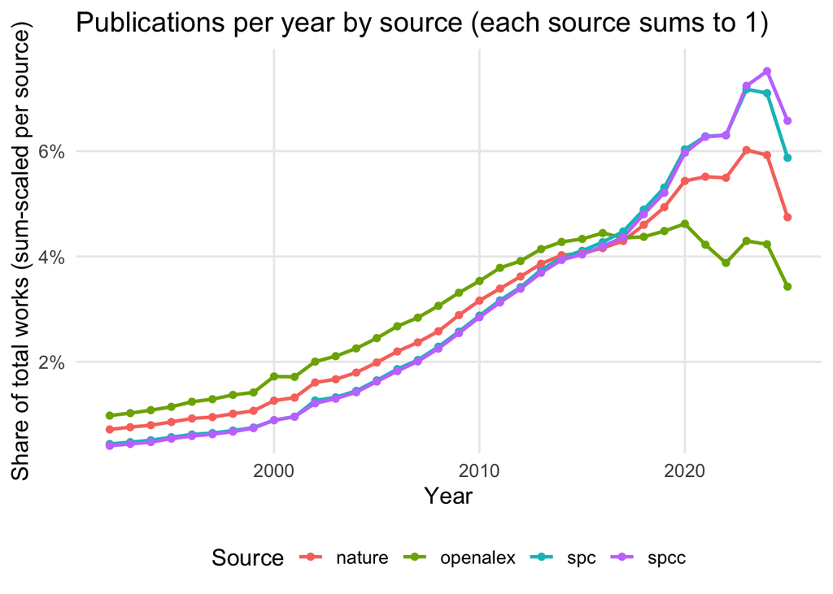

```r
readRDS(file.path(params$corpus, "st_years.rds")) |>
  tidyr::pivot_longer(
    cols = dplyr::starts_with("count_"),
    names_to = "source",
    values_to = "count",
    names_prefix = "count_"
  ) |>
  # scale each source so its total sum is 1
  dplyr::group_by(source) |>
  dplyr::mutate(
    total_count = base::sum(count, na.rm = TRUE),
    count = dplyr::if_else(total_count > 0, count / total_count, 0)
  ) |>
  dplyr::ungroup() |>
  dplyr::select(-total_count) |>
  ggplot2::ggplot(ggplot2::aes(x = year, y = count, color = source)) +
  ggplot2::geom_line(linewidth = 1) +
  ggplot2::geom_point(size = 1.5) +
  ggplot2::scale_y_continuous(
    labels = scales::label_percent(accuracy = 1),
    expand = ggplot2::expansion(mult = c(0.02, 0.06))
  ) +
  ggplot2::labs(
    x = "Year",
    y = "Share of total works (sum-scaled per source)",
    color = "Source",
    title = "Publications per year by source (each source sums to 1)"
  ) +
  ggplot2::theme_minimal(base_size = 14) +
  ggplot2::theme(
    legend.position = "bottom",
    panel.grid.minor = ggplot2::element_blank()
  )
```

#### Language

```r
readRDS(file.path(params$corpus, "st_languages.rds")) |>
  dplyr::mutate(
    dplyr::across(
      dplyr::starts_with("count_"),
      ~ base::format(.x, big.mark = ",")
    )
  ) |>
  knitr::kable(format = "html", escape = FALSE)
```

| language | count_openalex | count_spc | count_nature | count_spcc |
| --- | --- | --- | --- | --- |
| English | 148,846,144 | 5,288,696 | 22,525,939 | 2,845,795 |
| Spanish | 8,000,764 | 71,029 | 352,929 | 30,375 |
| Japanese | 7,787,128 | 1,701 | 14,813 | 847 |
| French | 5,980,155 | 38,307 | 269,824 | 20,131 |
| German | 5,957,848 | 13,895 | 63,583 | 5,261 |
| Chinese | 4,526,511 | 4,051 | 36,358 | 2,013 |
| Portuguese | 4,330,547 | 31,673 | 139,789 | 16,513 |
| Indonesian | 3,065,227 | 42,083 | 168,957 | 15,798 |
| Korean | 3,004,656 | 27,795 | 101,468 | 13,631 |
| Russian | 2,812,938 | 28,366 | 148,424 | 15,485 |
| Italian | 1,359,451 | 7,301 | 33,437 | 4,414 |
| Polish | 1,266,118 | 4,473 | 25,693 | 2,534 |
| Turkish | 884,257 | 5,415 | 26,426 | 2,932 |
| Dutch | 828,958 | 2,198 | 12,452 | 1,177 |
| Arabic | 734,494 | 3,589 | 18,948 | 1,541 |
| Ukrainian | 552,998 | 5,810 | 23,068 | 3,339 |
| Swedish | 512,579 | 5,564 | 18,269 | 2,606 |
| Persian | 489,990 | 2,521 | 7,940 | 1,539 |
| Czech | 486,942 | 4,093 | 18,998 | 1,659 |
| Catalan | 322,723 | 1,284 | 8,898 | 726 |
| Croatian | 228,056 | 3,082 | 13,735 | 1,586 |
| Norwegian | 196,452 | 1,068 | 4,788 | 505 |
| Finnish | 189,852 | 864 | 3,587 | 427 |
| Latvian | 188,932 | 2,863 | 13,130 | 606 |
| Hungarian | 175,778 | 1,582 | 7,548 | 820 |
| Modern Greek (1453-) | 161,551 | 1,083 | 4,300 | 571 |
| Danish | 160,609 | 334 | 2,692 | 147 |
| Malay (macrolanguage) | 153,050 | 2,710 | 10,498 | 1,346 |
| Slovenian | 107,001 | 830 | 3,894 | 448 |
| Thai | 106,295 | 2,476 | 5,129 | 875 |

[output cut: 100 more lines]

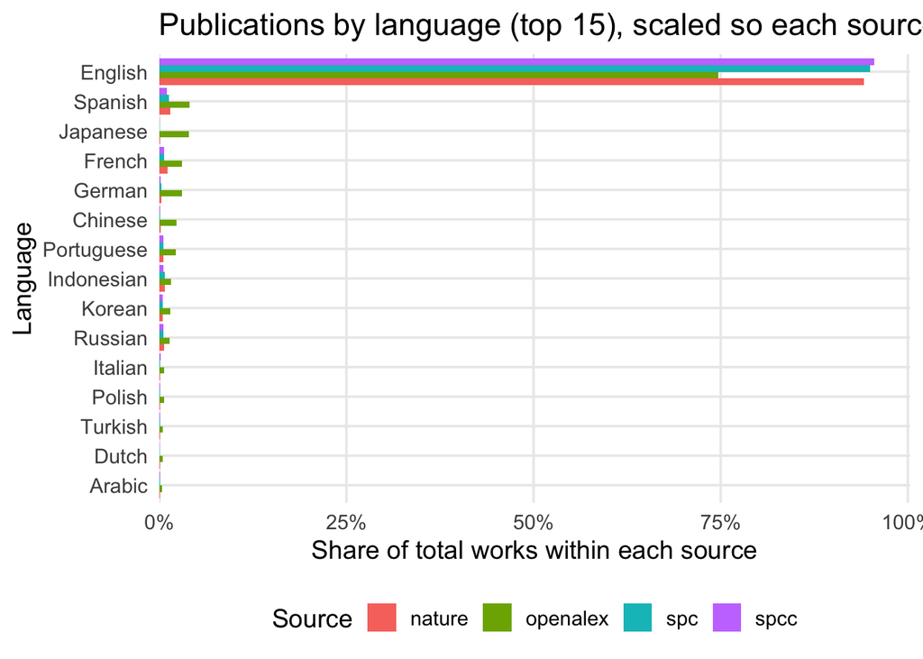

```r
readRDS(file.path(params$corpus, "st_languages.rds")) |>
  # keep top 15 languages by total (before scaling)
  dplyr::mutate(
    total = count_openalex + count_spc + count_nature + count_spcc
  ) |>
  dplyr::slice_max(total, n = 15) |>
  dplyr::arrange(dplyr::desc(total)) |>
  # fix display order so largest stays on top
  dplyr::mutate(language = factor(language, levels = rev(language))) |>
  dplyr::select(-total) |>
  # reshape wide → long
  tidyr::pivot_longer(
    cols = dplyr::starts_with("count_"),
    names_to = "source",
    values_to = "count",
    names_prefix = "count_"
  ) |>
  # scale so each source sums to 1
  dplyr::group_by(source) |>
  dplyr::mutate(
    total_source = base::sum(count, na.rm = TRUE),
    count = dplyr::if_else(total_source > 0, count / total_source, 0)
  ) |>
  dplyr::ungroup() |>
  dplyr::select(-total_source) |>
  ggplot2::ggplot(ggplot2::aes(x = language, y = count, fill = source)) +
  ggplot2::geom_col(position = "dodge") +
  ggplot2::coord_flip() +
  ggplot2::scale_y_continuous(
    labels = scales::label_percent(accuracy = 1),
    expand = ggplot2::expansion(mult = c(0, 0.05))
  ) +
  ggplot2::labs(
    x = "Language",
    y = "Share of total works within each source",
    fill = "Source",
    title = "Publications by language (top 15), scaled so each source sums to 1"
  ) +
  ggplot2::theme_minimal(base_size = 14) +
  ggplot2::theme(
    legend.position = "bottom",
    panel.grid.minor = ggplot2::element_blank()
  )
```

## Individual Chapter

Here we show the sub-searches for the individual chapters. In the tables indicating the number, an `NA` value indicates that the search string was to long (most likely) or any other error occured in the search. The same applies when an error message is given.

### Chapter 1

```r
ch1_hits <- readRDS(file.path(params$chapter_1, "st_hits.rds"))

ch1_counts <- setNames(ch1_hits$count, rownames(ch1_hits))

ch1_hits |>
  dplyr::mutate(count = format_count(count)) |>
  knitr::kable(
    col.names = c("Count"),
    align = "r"
  )
```

|  | Count |
| --- | --- |
| Set 1 | 4,411 |
| Set 2.1 | 4,984 |
| Set 2.2 | 94 |
| Set 3 | 28,006 |

```r
render_mermaid(
  file.path("figures", "chapter1.mmd"),
  c(
    C1_1 = format_count(ch1_counts[["Set 1"]]),
    C1_2.1 = format_count(ch1_counts[["Set 2.1"]]),
    C1_2.2 = format_count(ch1_counts[["Set 2.2"]]),
    C1_3 = format_count(ch1_counts[["Set 3"]])
    # C1_4 = format_count(ch1_counts[["Set 4"]]),
    # C1_5 = format_count(ch1_counts[["Set 5"]]),
    # C1_6 = format_count(ch1_counts[["Set 6"]]),
    # C1_7 = format_count(ch1_counts[["Set 7"]])
  )
)
```

```
%%{init: {'flowchart': {'htmlLabels': true}}}%%
flowchart LR
    Start([SPC Corpus]) --> Ch1["<u><span style='color:#1a0dab;'>chapter_1.yaml<br/>Level 2 refinements</span></u>"]
    click Ch1 "./input/search_terms/chapter_1.yaml" "Open chapter_1.yaml"

    subgraph Chapter1Sets["Chapter 1 thematic searches"]
        direction TB
        C1_1["Set 1:<br/>land/spatial planning<br/>+ biodiversity goals<br/>+ societal needs/values<br/>(n = 4,411)"]
        C1_2.1["Set 2.1:<br/>???<br/>(n = 4,984)"]
        C1_2.2["Set 2.2:<br/>???<br/>(n = 94)"]
        C1_3["Set 3:<br/>evidence & precaution<br/>+ ILK knowledge base<br/>(n = 28,006)"]
        %% C1_4["Set 4:<br/>multilevel/transparent governance<br/>+ customary coherence<br/>(n = <<C1_4>>)"]
        %% C1_5["Set 5:<br/>participatory planning<br/>+ co-design / engagement<br/>(n = <<C1_5>>)"]
        %% C1_6["Set 6:<br/>equity / rights / tenure<br/>+ justice outcomes<br/>(n = <<C1_6>>)"]
        %% C1_7["Set 7:<br/>connectivity (land-sea/cross-scale)<br/>+ nexus & climate links<br/>(n = <<C1_7>>)"]
    end

    Ch1 --> C1_1
    Ch1 --> C1_2.1
    Ch1 --> C1_2.2
    Ch1 --> C1_3
    %% Ch1 --> C1_4
    %% Ch1 --> C1_5
    %% Ch1 --> C1_6
    %% Ch1 --> C1_7
```

### Chapter 2

In addition to the search terms, only works which have at least one identified SDG are returned.

```r
ch2_hits <- readRDS(file.path(params$chapter_2, "st_hits.rds"))

# ch2_counts <- lapply(
#   ch2_hits,
#   function(df) {
#     setNames(df$count, rownames(df))
#   }
# )

ch2_counts <- setNames(ch2_hits$count, rownames(ch2_hits))

ch2_hits |>
  dplyr::mutate(count = format_count(count)) |>
  knitr::kable(
    col.names = c("Count"),
    align = "r"
  )
```

|  | Count |
| --- | --- |
| Set 1.1 | 152,903 |
| Set 1.2 | 2,660 |
| Set 1.3 | 78,268 |
| Set 1.4 | 56,634 |
| Set 2.1 | 940,546 |
| Set 2.2 | 287,119 |

```r
#|
render_mermaid(
  file.path("figures", "chapter2.mmd"),
  c(
    Set_11 = format_count(ch2_counts[["Set 1.1"]]),
    Set_12 = format_count(ch2_counts[["Set 1.2"]]),
    Set_13 = format_count(ch2_counts[["Set 1.3"]]),
    Set_14 = format_count(ch2_counts[["Set 1.4"]]),
    Set_21 = format_count(ch2_counts[["Set 2.1"]]),
    Set_22 = format_count(ch2_counts[["Set 2.2"]])
  )
)
```

```
%%{init: {'flowchart': {'htmlLabels': true}}}%%
flowchart LR
    Start([SPC Corpus]) --> Ch2L2["<u><span style='color:#1a0dab;'>chapter_2.yaml<br/>Level 2 GBF bundles</span></u>"]
    click Ch2L2 "../search_terms/chapter_2.yaml" "Open chapter_2.yaml"

    subgraph Chapter2Sets["GBF contexts & targets"]
        direction TB
        Set_11["Set 1.1<br/>(n = 152,903)"]
        Set_12["Set 1.2<br/>(n = 2,660)"]
        Set_13["Set 1.3<br/>(n = 78,268)"]
        Set_14["Set 1.3<br/>(n = 56,634)"]
        Set_21["Set 2.1<br/>(n = 940,546)"]
        Set_22["Set 2.2<br/>(n = 287,119)"]
        %% Set_3["Set 3<br/>(n = <<Set_3>>)"]
    end
    Ch2L2 --> Set_11
    Ch2L2 --> Set_12
    Ch2L2 --> Set_13
    Ch2L2 --> Set_21
    Ch2L2 --> Set_22
    %% Ch2L2 --> Set_3

    %% subgraph L1_TARGET["GBF contexts & targets"]
    %%     T3["Target 3<br/>(n = <<T3>>)"]
    %%     T4["Target 4<br/>(n = <<T4>>)"]
    %%     T5["Target 5<br/>(n = <<T5>>)"]
    %%     T6["Target 6<br/>(n = <<T6>>)"]
    %%     T7["Target 7<br/>(n = <<T7>>)"]
    %%     T8["Target 8<br/>(n = <<T8>>)"]
    %%     T9["Target 9<br/>(n = <<T9>>)"]
    %%     T10["Target 10<br/>(n = <<T10>>)"]
    %%     T11["Target 11<br/>(n = <<T11>>)"]
    %%     T12["Target 12<br/>(n = <<T12>>)"]
    %%     T13["Target 13<br/>(n = <<T13>>)"]
    %%     T14["Target 14<br/>(n = <<T14>>)"]
    %%     T15["Target 15<br/>(n = <<T15>>)"]
    %%     T16["Target 16<br/>(n = <<T16>>)"]
    %%     T17["Target 17<br/>(n = <<T17>>)"]
    %%     T18["Target 18<br/>(n = <<T18>>)"]
    %%     T19["Target 19<br/>(n = <<T19>>)"]
```

[output cut: 70 more lines]

```
    %% Ch2L4 --> SDG3
    %% Ch2L4 --> SDG4
    %% Ch2L4 --> SDG5
    %% Ch2L4 --> SDG6
    %% Ch2L4 --> SDG7
    %% Ch2L4 --> SDG8
    %% Ch2L4 --> SDG9
    %% Ch2L4 --> SDG10
    %% Ch2L4 --> SDG11
    %% Ch2L4 --> SDG12
    %% Ch2L4 --> SDG13
    %% Ch2L4 --> SDG14
    %% Ch2L4 --> SDG15
    %% Ch2L4 --> SDG16
    %% Ch2L4 --> SDG17
```

#### Deduplicated within each Set

```r
file.path(params$chapter_2, "corpus.openalex_pro", "corpus_set_deduped") |>
  arrow::open_dataset() |>
  dplyr::summarize(n = n(), .by = c(set)) |>
  dplyr::collect()
```

| set | n |
| --- | --- |
| Set 1 | 200969 |
| Set 2 | 1071559 |

#### Final Corpus

```r
cf <-
  file.path(
    params$chapter_2,
    "corpus.openalex_pro",
    "corpus_final"
  ) |>
  arrow::open_dataset()

print("Columns in the final corpus:")
```

```
[1] "Columns in the final corpus:"
```

```r
names(cf)
```

```
 [1] "id"                            "doi"
 [3] "citation"                      "title"
 [5] "abstract"                      "type"
 [7] "language"                      "open_access"
 [9] "primary_location"              "sustainable_development_goals"
[11] "oa_status"                     "journal"
[13] "publication_year"
```

```r
print("Number of individual works (rows):")
```

```
[1] "Number of individual works (rows):"
```

```r
nrow(cf) |>
  format(big.mark = ",")
```

```
[1] "122,621"
```

### Chapter 3

```r
ch3_hits <- readRDS(file.path(params$chapter_3, "st_hits.rds"))

ch3_counts <- setNames(ch3_hits$count, rownames(ch3_hits))

ch3_hits |>
  dplyr::mutate(count = format_count(count)) |>
  knitr::kable(
    col.names = c("Count"),
    align = "r"
  )
```

|  | Count |
| --- | --- |
| Set 1 | 12,766 |
| Set 3 | 3,598 |
| Set 3.1A | 964 |
| Set 3.1BCD | 311 |
| Set 3.2CE | 366 |
| Set 3.2D | 2,121 |
| Set 3.2F | 187 |
| Set 3.3 | 4,065 |
| Set 4 | 21,951 |
| Set 4.1AB | 1,858 |
| Set 4.1CD | 12,867 |
| Set 4.2 | 11,921 |
| Set 5.1 | 2,223 |
| Set 5.2 | 1,071 |

```r
render_mermaid(
  file.path("figures", "chapter3.mmd"),
  c(
    C3_1 = format_count(ch3_counts[["Set 1"]]),
    C3_3 = format_count(ch3_counts[["Set 3"]]),
    C3_3.1A = format_count(ch3_counts[["Set 3.1A"]]),
    C3_3.1BCD = format_count(ch3_counts[["Set 3.1BCD"]]),
    C3_3.2D = format_count(ch3_counts[["Set 3.2D"]]),
    C3_3.2F = format_count(ch3_counts[["Set 3.2F"]]),
    C3_3.3 = format_count(ch3_counts[["Set 3.3"]]),
    C3_4 = format_count(ch3_counts[["Set 4"]]),
    C3_4.1AB = format_count(ch3_counts[["Set 4.1AB"]]),
    C3_4.1CD = format_count(ch3_counts[["Set 4.1CD"]]),
    C3_4.2 = format_count(ch3_counts[["Set 4.2"]]),
    C3_5.1 = format_count(ch3_counts[["Set 5.1"]]),
    C3_5.2 = format_count(ch3_counts[["Set 5.2"]])
  )
)
```

```
%%{init: {'flowchart': {'htmlLabels': true}}}%%
flowchart LR
    Start([SPC Corpus]) --> Ch3["<u><span style='color:#1a0dab;'>chapter_3.yaml<br/>Level 2 refinements</span></u>"]
    click Ch3 "./input/search_terms/chapter_3.yaml" "Open chapter_3.yaml"

    subgraph Chapter3Sets["Chapter 3 searches"]
        direction TB
        C3_1["Set 1:<br/>Protected/OECM + NBSAP + cases<br/>+ spatial prioritization + regional scales<br/>(n = 12,766)"]
        C3_3["Set 3:<br/>Restoration planning + connectivity + resilience<br/>(n = 3,598)"]
        C3_3.1A["Set 3.1 A:<br/>Objective<br/>(n = 964)"]
        C3_3.1BCD["Set 3.1 BCD:<br/>Concept<br/>(n = 311)"]
        C3_3.2D["Set 3.2 D:<br/>???<br/>(n = 2,121)"]
        C3_3.2F["Set 3.2 F:<br/>???<br/>(n = 187)"]
        C3_3.3["Set 3.3:<br/>???<br/>(n = 4,065)"]
        C3_4["Set 4:<br/>Systematic conservation planning / gap analysis<br/>(n = 21,951)"]
        C3_4.1AB["Set 4.1 AB:<br/>???<br/>(n = 1,858)"]
        C3_4.1CD["Set 4.1 CD:<br/>???<br/>(n = 12,867)"]
        C3_4.2["Set 4.2:<br/>???<br/>(n = 11,921)"]

        C3_5.1["Set 5.1:<br/>???<br/>(n = 2,223)"]
        C3_5.2["Set 5.1:<br/>???<br/>(n = 1,071)"]
    end
    Ch3 --> C3_1
    Ch3 --> C3_3
    Ch3 --> C3_3.1A
    Ch3 --> C3_3.1BCD
    Ch3 --> C3_3.2D
    Ch3 --> C3_3.2F
    Ch3 --> C3_3.3
    Ch3 --> C3_4
    Ch3 --> C3_4.1AB
    Ch3 --> C3_4.1CD
    Ch3 --> C3_4.2
    Ch3 --> C3_5.1
    Ch3 --> C3_5.2
```

### Chapter 4

```r
ch4_hits <- readRDS(file.path(params$chapter_4, "st_hits.rds"))

ch4_counts <- setNames(ch4_hits$count, rownames(ch4_hits))

ch4_hits |>
  dplyr::mutate(count = format_count(count)) |>
  knitr::kable(
    col.names = c("Count"),
    align = "r"
  )
```

|  | Count |
| --- | --- |
| Set 1 | 1,387 |
| Set 2 | 241 |
| Set 3 | 6,290 |
| Set 4 | 29,809 |
| Set 5 | 375 |
| Set 6 | 2,676 |
| Set 7 | 0 |
| Set 8 | 89,971 |

```r
render_mermaid(
  file.path("figures", "chapter4.mmd"),
  c(
    C4_1 = format_count(ch4_counts[["Set 1"]]),
    C4_2 = format_count(ch4_counts[["Set 2"]]),
    C4_3 = format_count(ch4_counts[["Set 3"]]),
    C4_4 = format_count(ch4_counts[["Set 4"]]),
    C4_5 = format_count(ch4_counts[["Set 5"]]),
    C4_6 = format_count(ch4_counts[["Set 6"]]),
    C4_7 = format_count(ch4_counts[["Set 7"]]),
    C4_8 = format_count(ch4_counts[["Set 8"]])
  )
)
```

```
%%{init: {'flowchart': {'htmlLabels': true}}}%%
flowchart LR
    Start([SPC Corpus]) --> Ch4["<u><span style='color:#1a0dab;'>chapter_4.yaml<br/>Level 2 refinements</span></u>"]
    click Ch4 "./input/search_terms/chapter_4.yaml" "Open chapter_4.yaml"

    subgraph Chapter4Sets["Chapter 4 searches"]
        direction TB
        C4_1["Set 1:<br/>Connectivity review articles<br/>(n = 1,387)"]
        C4_2["Set 2:<br/>Connectivity benefits vs risks<br/>+ ecosystem services<br/>(n = 241)"]
        C4_3["Set 3:<br/>Structural vs functional connectivity<br/>(n = 6,290)"]
        C4_4["Set 4:<br/>Connectivity modelling toolkits<br/>(n = 29,809)"]
        C4_5["Set 5:<br/>Connectivity indicators & metrics<br/>(n = 375)"]
        C4_6["Set 6:<br/>Policy & governance integration<br/>(n = 2,676)"]
        C4_7["Set 7:<br/>Multilevel / transboundary governance<br/>+ IPLC inclusion + land tenure<br/>(n = 0)"]
        C4_8["Set 8:<br/>Movement ecology<br/>(dispersal / migration / permeability)<br/>(n = 89,971)"]
    end
    Ch4 --> C4_1
    Ch4 --> C4_2
    Ch4 --> C4_3
    Ch4 --> C4_4
    Ch4 --> C4_5
    Ch4 --> C4_6
    Ch4 --> C4_7
    Ch4 --> C4_8
```

### Chapter 5

```r
ch5_hits <- readRDS(file.path(params$chapter_5, "st_hits.rds"))

ch5_counts <- lapply(ch5_hits, function(df) {
  setNames(df$count, rownames(df))
})

do.call(
  rbind,
  lapply(names(ch5_hits), function(sect_nm) {
    df <- ch5_hits[[sect_nm]]
    df$section <- sect_nm
    df$set <- rownames(df)
    rownames(df) <- NULL
    df[,
      c("section", "set", setdiff(names(df), c("section", "set"))),
      drop = FALSE
    ]
  })
) |>
  dplyr::mutate(
    count = format_count(count)
  ) |>
  knitr::kable(
    col.names = c("Section", "Set", "Count"),
    align = c("c", "c", "r")
  )
```

| Section | Set | Count |
| --- | --- | --- |
| Sections 1 and 2 | Set 1 | 203,060 |
| Sections 1 and 2 | Set 2 | 62,688 |
| Sections 1 and 2 | Set 3 | 61,473 |
| Sections 1 and 2 | Set 4 | 425,315 |
| Sections 1 and 2 | Set 5 | 267,697 |
| Section 3 | Set 1 | 2,919 |
| Section 3 | Set 2 | 15,626 |
| Section 3 | Set 3 | 117 |
| Section 4 | Set 1 | 63,322 |
| Section 4 | Set 2 | 21,664 |
| Section 4 | Set 3 | 14,256 |
| Section 5 | Set 1 | 15,193 |
| Section 5 | Set 2 | 84,675 |
| Section 5 | Set 3 | 53,802 |
| Section 5 | Set 4 | 29,203 |
| Section 6 | Set 1 | 180 |
| Section 6 | Set 2 | 4,258 |
| Section 6 | Set 3 | 3,121 |
| Section 6 | Set 4 | 2,521 |
| Cross-cutting sets | Set 1 | 45,650 |
| Cross-cutting sets | Set 2 | 232,690 |

```r
fmt_ch5 <- function(section, set) {
  format_count(ch5_counts[[section]][[set]])
}

render_mermaid(
  file.path("figures", "chapter5.mmd"),
  c(
    C5_1 = fmt_ch5("Sections 1 and 2", "Set 1"),
    C5_2 = fmt_ch5("Sections 1 and 2", "Set 2"),
    C5_3 = fmt_ch5("Sections 1 and 2", "Set 3"),
    C5_4 = fmt_ch5("Sections 1 and 2", "Set 4"),
    C5_5 = fmt_ch5("Sections 1 and 2", "Set 5"),
    C5_3a = fmt_ch5("Section 3", "Set 1"),
    C5_3b = fmt_ch5("Section 3", "Set 2"),
    C5_3c = fmt_ch5("Section 3", "Set 3"),
    C5_4a = fmt_ch5("Section 4", "Set 1"),
    C5_4b = fmt_ch5("Section 4", "Set 2"),
    C5_4c = fmt_ch5("Section 4", "Set 3"),
    C5_5a = fmt_ch5("Section 5", "Set 1"),
    C5_5b = fmt_ch5("Section 5", "Set 2"),
    C5_5c = fmt_ch5("Section 5", "Set 3"),
    C5_5d = fmt_ch5("Section 5", "Set 4"),
    C5_6a = fmt_ch5("Section 6", "Set 1"),
    C5_6b = fmt_ch5("Section 6", "Set 2"),
    C5_6c = fmt_ch5("Section 6", "Set 3"),
    C5_6d = fmt_ch5("Section 6", "Set 4"),
    CC1 = fmt_ch5("Cross-cutting sets", "Set 1"),
    CC2 = fmt_ch5("Cross-cutting sets", "Set 2")
  )
)
```

```
%%{init: {'flowchart': {'htmlLabels': true}}}%%
flowchart LR
    Start([SPC Corpus]) --> Ch5L2["<u><span style='color:#1a0dab;'>chapter_5.yaml<br/>Level 2 foresight framing</span></u>"]
    click Ch5L2 "./input/search_terms/chapter_5.yaml" "Open chapter_5.yaml"

    subgraph L2Sets["Section 5.1–5.2 searches"]
        direction TB
        C5_1["Set 1:<br/>Future + project*/predict*/scenario<br/>(n = 203,060)"]
        C5_2["Set 2:<br/>Future + pathway*/narrative*/vision*<br/>(n = 62,688)"]
        C5_3["Set 3:<br/>Future-proof*/anticipat*/scenario planning<br/>(n = 61,473)"]
        C5_4["Set 4:<br/>Foresight*/backcasting/simulat*/trend*<br/>(n = 425,315)"]
        C5_5["Set 5:<br/>Model* AND scenario<br/>(n = 267,697)"]
    end
    Ch5L2 --> C5_1
    Ch5L2 --> C5_2
    Ch5L2 --> C5_3
    Ch5L2 --> C5_4
    Ch5L2 --> C5_5

    subgraph L3Sets["Section 5.3 searches"]
        direction TB
        C5_3a["Set 1:<br/>Drivers of change<br/>(n = 2,919)"]
        C5_3b["Set 2:<br/>Driver modelling approaches<br/>(n = 15,626)"]
        C5_3c["Set 3:<br/>Driver gaps<br/>(n = 117)"]
    end
    Ch5L2 --> C5_3a
    Ch5L2 --> C5_3b
    Ch5L2 --> C5_3c

    subgraph L4Sets["Section 5.4 searches"]
        direction TB
        C5_4a["Set 1:<br/>Interactions (synergy/trade-off/nexus)<br/>(n = 63,322)"]
        C5_4b["Set 2:<br/>Response options (integrated planning / NbS)<br/>(n = 21,664)"]
        C5_4c["Set 3:<br/>Cross-scale synergy & trade-off terms<br/>(n = 14,256)"]
    end
    Ch5L2 --> C5_4a
    Ch5L2 --> C5_4b
    Ch5L2 --> C5_4c

    subgraph L5Sets["Section 5.5 searches"]
```

[output cut: 15 more lines]

```
        C5_6c["Set 3:<br/>Enabling factors & coordination<br/>(n = 3,121)"]
        C5_6d["Set 4:<br/>Shocks, surprises, uncertainties<br/>(n = 2,521)"]
    end
    Ch5L2 --> C5_6a
    Ch5L2 --> C5_6b
    Ch5L2 --> C5_6c
    Ch5L2 --> C5_6d

    subgraph CCSets["Cross-cutting searches"]
        direction TB
        CC1["Set 1:<br/>Scales & telecoupling<br/>(n = 45,650)"]
        CC2["Set 2:<br/>Co-production & inclusion<br/>(n = 232,690)"]
    end
    Ch5L2 --> CC1
    Ch5L2 --> CC2
```

### Chapter 6

```r
ch6_hits <- readRDS(file.path(params$chapter_6, "st_hits.rds"))

ch6_counts <- setNames(ch6_hits$count, rownames(ch6_hits))

ch6_hits |>
  dplyr::mutate(count = format_count(count)) |>
  knitr::kable(
    col.names = c("Count"),
    align = "r"
  )
```

[output not shown]

```r
render_mermaid(
  file.path("figures", "chapter6.mmd"),
  c(
    C6_1 = format_count(ch6_counts[["Set 1"]]),
    C6_2 = format_count(ch6_counts[["Set 2"]]),
    C6_3 = format_count(ch6_counts[["Set 3"]]),
    C6_4 = format_count(ch6_counts[["Set 4"]]),
    C6_5 = format_count(ch6_counts[["Set 5"]]),
    C6_6 = format_count(ch6_counts[["Set 6"]]),
    C6_7 = format_count(ch6_counts[["Set 7"]]),
    C6_8 = format_count(sum(ch6_counts[c("Set 8.1", "Set 8.2")], na.rm = TRUE)),
    C6_9 = format_count(ch6_counts[["Set 9"]]),
    C6_10 = format_count(ch6_counts[["Set 10"]])
  )
)
```

[output not shown]